# Using Q-methodology in environmental sustainability research: A bibliometric analysis and systematic review - ScienceDirect

## Outline

1. 1. Introduction
2. 2. Q-methodology: history and protocol
3. 3. Methodology
4. 4. Bibliometric results and discussion
5. 5. Q-method application results
6. 6. Gaps and limitations in Q-method research
7. 7. Best practices in Q-methodology research
8. 8. Conclusion
9. Declaration of Competing Interest
10. Acknowledgements
11. Appendix A. Supplementary data
12. References

## Figures (5)

[figure not shown]

[figure not shown]

[figure not shown]

## Tables (5)

1. Table 1
2. Table 2
3. Table 3
4. Table 4
5. Table 5

## Extras (1)

1. Supplementary material

## [Ecological Economics](https://www.sciencedirect.com/science/journal/09218009)

[Volume 180](https://www.sciencedirect.com/science/journal/09218009/180/supp/C), February 2021, 106864

# Using Q-methodology in environmental sustainability research: A bibliometric analysis and systematic review

[GretchenSneegas<sup>a</sup>](https://www.sciencedirect.com/science/article/pii/S0921800920309654#!)[SydneyBeckner<sup>b</sup>](https://www.sciencedirect.com/science/article/pii/S0921800920309654#!)[ChristianBrannstrom<sup>a</sup>](https://www.sciencedirect.com/science/article/pii/S0921800920309654#!)[WendyJepson<sup>a</sup>](https://www.sciencedirect.com/science/article/pii/S0921800920309654#!)[KyungsunLee<sup>a</sup>](https://www.sciencedirect.com/science/article/pii/S0921800920309654#!)[LucasSeghezzo<sup>c</sup>](https://www.sciencedirect.com/science/article/pii/S0921800920309654#!)

https://doi.org/10.1016/j.ecolecon.2020.106864[Get rights and content](https://s100.copyright.com/AppDispatchServlet?publisherName=ELS&contentID=S0921800920309654&orderBeanReset=true)

Under a Creative Commons [license](https://creativecommons.org/licenses/by-nc-nd/4.0/)

open access

## 1. Introduction

Since its first mention in *Ecological Economics* over two decades ago (Barry and Proops, 1999), numerous socio-environmental researchers have adopted Q-methodology to investigate social perspectives on environmental governance. Q-methodology, hereafter referred to as “Q-method,” is a mixed qualitative-quantitative approach that offers replicable steps to elicit key stakeholders' social perspectives on a wide-ranging set of issues that directly bear on the efficacy, barriers, and social processes in environmental policymaking and governance. Since Barry and Proops' influential paper, environmental social scientists have used Q-method to empirically determine different social perspectives among key actors involved in decision making around the sustainable conservation and management of natural resources, demonstrating its effectiveness for understanding “the interlinkages in opinions between topics or patterns of perspectives” (Mukherjee et al., 2018: 57).

Stakeholder perspectives are increasingly recognized as important for socio-environmental research, with growing demand for engaging stakeholders across research activities. Q-method is frequently used to delineate and understand different stakeholder perspectives across such diverse fields as energy, land use, fisheries management, mining, wildlife conservation, agriculture, and water resource management, making it particularly salient as a means to inform sustainability practice and policy. Q-method offers researchers replicable, evidence-based results that may support decision-makers in management options assessment, critical reflection, policy appraisal and acceptability, and conflict resolution (Zabala et al., 2018). This paper takes a closer look at the last 18 years of Q-methodological socio-environmental work in terms of its strengths and weaknesses. We aim to provide researchers wishing to engage stakeholder perspectives with clearer guidelines on Q-method application, analysis, and reporting.

To the best of our knowledge, no publication has reviewed the recent growth in socio-environmental Q-method research used to study stakeholder perspectives on socio-environmental topics.<sup>1</sup> This existing body of Q-method research is highly heterogeneous in terms of methodological practice and reporting strategies, but has yet to be catalogued and analyzed. A more comprehensive review of the method's application in the field is needed to establish research trends, shared gaps, and best practices.

We address this need by conducting a systematic review and bibliometric analysis of empirical Q-method studies on environmental sustainability. First, we examine the status and trends of current Q-method scholarship on environmental sustainability, defined for the purposes of this review as relating to the sustainable conservation and management of natural resources as a key site of socio-environmental interaction. We develop and analyze a corpus of 277 empirical Q-method studies published in peer reviewed journals between 2000 and 2018. Second, we identify gaps in this literature in terms of research design, practice, analysis, and geographic coverage. Our analysis illustrates considerable heterogeneity in the application of Q-method, exposing many publications that are opaque regarding decisions in study design and data analysis. Third, we synthesize best practices for addressing these gaps and highlight best practices for conducting and reporting Q-method research.

## 2. Q-methodology: history and protocol

William Stephenson, 1935, Stephenson, 1953, a physicist and psychologist, developed Q-method in the mid-20th Century. Rather than treating the participants as the study's *n* and their viewpoints as the variables, as in traditional factor analysis, Stephenson analyzed participants' viewpoints as the study's *n* and participants as its variables, correlating between participants instead of viewpoints. Q-method views subjectivity as *operant*, meaning an individual's subjectivity is observable through their behavior and performed by expressing “a point of view about something concrete” from an internal frame of reference (Robbins and Krueger, 2000: 637). In a Q-method study, participants perform their subjectivity by rank-ordering subjective statements about the research topic. The factors produced *via* Q-method thus represent clusters of shared subjective perspectives within the participant pool.

Q-method merges quantitative and qualitative approaches by using factor analysis to identify and extract shared subjective viewpoints among participants. When used appropriately, Q-method produces “key viewpoints extant among a group of participants and allows those viewpoints to be understood holistically and to a high level of qualitative detail” (Watts and Stenner, 2012: 4). However, Q-method does not produce data that is generalizable to the broader population. The social perspectives produced through Q-method analysis can be expected to exist outside the study participant group, but not in the same proportions. Further, the social perspectives emerging from Q-method analysis may not encompass all possible perspectives on the domain of inquiry.

Q-methodology comprises a set of standardized steps after identifying a topic of study: (1) identifying study participants, or the *p-set*; (2) developing the study *concourse* and *Q-set*, comprising representative subjective statements on the research topic; (3) collecting data in the form of *Q-sorts* as participants rank-order the Q-set items; and (4) by-person factor analysis of the Q-sorts and subsequent interpretation (Robbins and Krueger, 2000; Watts and Stenner, 2012; McKeown and Thomas, 2013). The researchers' subjective knowledge of the domain under study informs each step and interpretation of the quantitative results.

Numerous critiques have been leveraged towards Q-method. While fully addressing these arguments falls outside the scope of this review, which instead catalogues trends, gaps, and best practices within published socio-environmental Q-method research, we provide a short summary here to situate our analysis. Kampen and Tamás (2014) argue Q-method lacks measurement and internal validity, thereby rendering it useless for scientific inquiry. Drawing from a systematic review of 39 empirical Q-studies published in 2010, the authors note a lack of clarity in the literature on concourse and p-set sampling, analysis, and interpretation methods. They further question the premise that Q-method accurately measures what it claims to measure – that is, subjective positions of study participants. Brown et al. (2015) argue these critiques misinterpret the theoretical foundations of Q-method, particularly regarding how subjectivity is conceptualized and defined, by viewing subjectivity as a set, determined “psychological or mental state” in contrast to Stephenson's view of subjectivity as operant (527).

Kampen and Tamás' criticisms parallel many constructivist Q-method critiques, such as questioning whether a concourse can encompass the entirety of a subjective domain and probing the elision of researchers' own subjective decisions throughout the Q-method process (Robbins and Krueger, 2000; Eden et al., 2005; Nost et al., 2019; Sneegas, 2020). Yet while Kampas and Tamás conclude these drawbacks render Q-method “inappropriate for its declared purpose, the scientific study of subjectivity” (2014: 3109), a constructivist approach instead views *all* scientific research as necessarily partial. From this perspective, Q-method critiques are best addressed by engaging critical reflexivity throughout study design, practice, and reporting stages. Our analysis aligns with these critiques that Q-method literature lacks clarity on its application and that Q-method users should pay greater attention to its subjective and interpretive dimensions. Despite the relative codification of Q-method protocol, we find significant variability across each research phase, indicating a need for greater researcher justification regarding their decisions on study design, data analysis, and interpretation.

## 3. Methodology

We conducted a systematic review to identify strengths and weaknesses in the existing body of Q-method research on environmental sustainability. A systematic review is a research method for summarizing the critical points of current knowledge on a given topic that answers a specific research question by matching pre-specified eligibility criteria. The lack of a comprehensive Q-method research review indicates that systematic review is an appropriate tool to survey the existing literature. We structured our analysis by following “Preferred Reporting Items for Systematic review and Meta-Analysis” (PRISMA) protocols. PRISMA outlines five steps for systematic review: 1) identify the research question; 2) develop a search protocol including databases, search strings and inclusion/exclusion criteria; 3) search the literature; 4) screen the collected literature based on title/abstract and full text; and 5) analysis (Moher et al., 2015).

Next, the papers were evenly divided among co-authors for the first iteration of processing. The research team used a shared Google form to collect data on each paper; co-authors did not collect data from their own Q-method publications. After all papers were processed into a master spreadsheet database, researchers qualitatively coded specific components of the corpus such as the p-set, Q-set, and factor extraction criteria. First, the researchers generated a preliminary list of qualitative categories to code each entry, refining the list of codes and generating sub-codes, and editing the database as needed. The research team members met several times to address inconsistencies and questions across the coding process, ensure common practices and shared understandings across the dataset, and further revise inclusion criteria for the corpus. After the processing and coding stages, an additional 55 papers that did not fit the revised inclusion criteria were removed for a final corpus of 277 papers (see S3 for complete list of reviewed articles). Fig. 1 summarizes our research process.

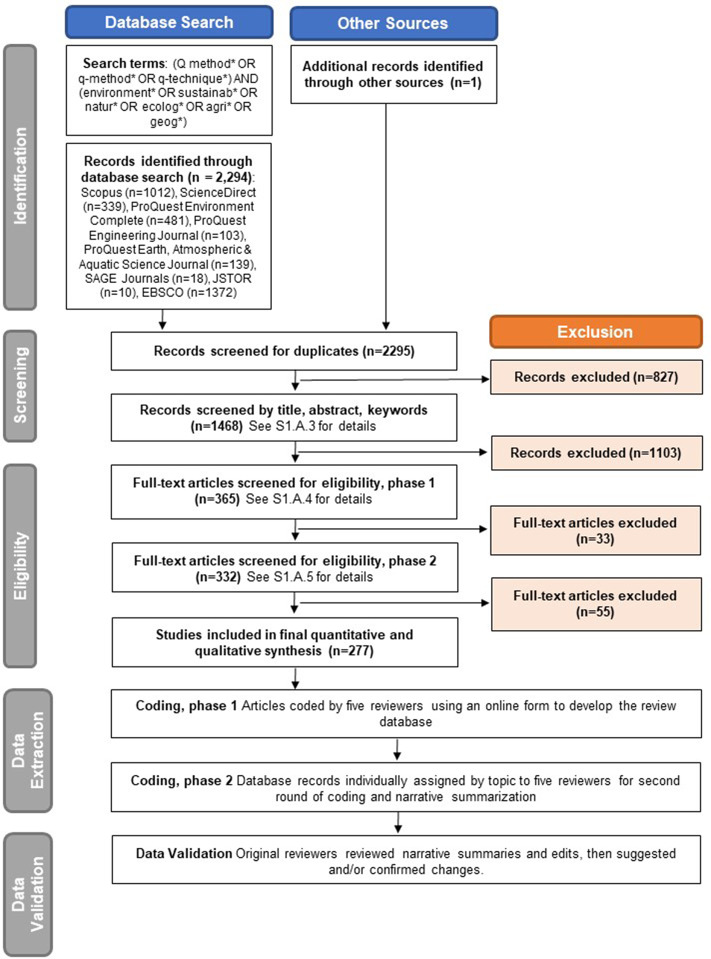

1. [Download : Download high-res image (523KB)](https://ars.els-cdn.com/content/image/1-s2.0-S0921800920309654-gr1_lrg.jpg)
2. [Download : Download full-size image](https://ars.els-cdn.com/content/image/1-s2.0-S0921800920309654-gr1.jpg)

Fig. 1. Systematic review process.

See S1.A for complete lists of all PRISMA criteria.

Bibliometric analysis provides information on characteristics of the domain under study, that is, levels of collaboration and information sharing between Q-method users. From these data, one can identify limits or gaps regarding the relative influence of one group over another, fragmentation, dispersion of within or across disciplines, and geographies of knowledge production. To examine trends in Q-method publication and authorship, we conducted several bibliometric analyses (see S1·B for detailed bibliometric analysis data). First, we analyzed the geography of researchers based on their institutional affiliation at time of publication. Second, we conducted a co-authorship and co-citation analysis using bibliographic network visualization tools VOSviewer (VOSviewer, 2020) and CitNetExplorer (CitNetExplorer, 2020) to identify influential papers and map relations between authors and research groups.<sup>2</sup>

## 4. Bibliometric results and discussion

Published Q-methodmm\ studies on sustainable natural resource governance increased sharply in the 2010s, with an average of 4 publications per year from 2000 to 2009 and an average of 26 per year from 2010 to 2018 (Fig. 2). Articles were published in a wide range of journals (*n* = 141). *Ecological Economics* published the highest number of Q-method case studies on environmental topics (*n* = 17), followed by *Sustainability* (*n* = 10); *Society & Natural Resources* (*n* = 8); and *Energy Policy*, *Geoforum*, and *Land Use Policy* (*n* = 7). Based on the authors' iterative coding, the most common sectors studied by the articles were agriculture (*n* = 39), water (*n* = 36), energy (*n* = 33), resource conservation (*n* = 27), and climate change (*n* = 23). Papers were coded for multiple sectors (see S1·B).

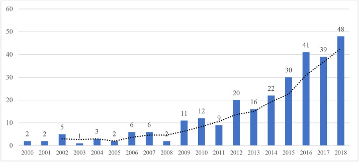

1. [Download : Download high-res image (125KB)](https://ars.els-cdn.com/content/image/1-s2.0-S0921800920309654-gr2_lrg.jpg)
2. [Download : Download full-size image](https://ars.els-cdn.com/content/image/1-s2.0-S0921800920309654-gr2.jpg)

Fig. 2. Published articles by year (2000–2018) with three-year moving average (dotted line).

Our analysis contained a total of 662 authors, 111 of whom had published two or more papers in the review corpus. We identified 159 research clusters, defined as a mutually exclusive set of connected researchers (Van Eck and Waltman, 2013). The research clusters range in size from 1 to 29 authors with an average of 4.16 and a mode of 2, demonstrating numerous yet highly disparate groups (Fig. 3). The small size and lack of co-authorship ties across most clusters indicates few collaborations between research groups.

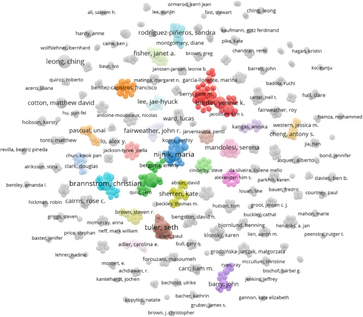

1. [Download : Download high-res image (404KB)](https://ars.els-cdn.com/content/image/1-s2.0-S0921800920309654-gr3_lrg.jpg)
2. [Download : Download full-size image](https://ars.els-cdn.com/content/image/1-s2.0-S0921800920309654-gr3.jpg)

Fig. 3. Co-authorship analysis*.

*Color is used to indicate research clusters with eight or more individuals. Grey indicates research clusters with seven or fewer individuals.

Table 1. 10 most-cited publications by papers in review corpus.<sup>a</sup>

| Author | Year | Title | Citations |
| --- | --- | --- | --- |
| Brown, S. R. | 1980 | *Political subjectivity: Applications of Q methodology in political science*. | 146 |
| Barry, J., & Proops, J. | 1999 | Seeking sustainability discourses with Q methodology | 91 |
| McKeown, B., & Thomas, D. | 1988 | *Q methodology* | 54 |
| Stephenson, W. | 1953 | The study of behavior; Q-technique and its methodology. | 53 |
| Watts, S., & Stenner, P. | 2012 | *Doing Q methodological research: Theory, method & interpretation* | 49 |
| Webler, T., Danielson, S., & Tuler, S. | 2009 | Using Q method to reveal social perspectives in environmental research. | 47 |
| Eden, S., Donaldson, A., & Walker, G. | 2005 | Structuring subjectivities? Using Q methodology in human geography | 47 |
| Watts, S., & Stenner, P. | 2005 | Doing Q methodology: theory, method and interpretation | 46 |
| Addams, H., & Proops, J. L. | 2000 | *Social discourse and environmental policy: an application of Q methodology*. | 42 |
| Robbins, P., & Krueger, R. | 2000 | Beyond bias? The promise and limits of Q method in human geography. | 41 |

**a**

Includes 217 papers in Web of Science database. Italicized titles indicate book manuscripts. Non-italicized titles indicate journal articles.

Table 2. Most-cited publications included in review corpus.<sup>a</sup>

| Citations | Publications |
| --- | --- |
| 31 | Ellis et al. (2007) |
| 27 | Davies and Hodge (2007) |
| 20 | Swedeen (2006) Cuppen et al. (2010) |
| 17 | Robbins (2006) |
| 15 | Frantzi et al. (2009) |
| 14 | Mattson et al. (2006) Niemeyer et al. (2005) Raadgever et al. (2008) |
| 13 | Clarke (2002) |
| 12 | Brannstrom (2011) |
| 10 | Brodt et al. (2006) Doody et al. (2009) Davies and Hodge (2012) |
| 9 | Wolsink (2004) Wolsink and Breukers (2010) Lansing (2013) |
| 8 | Fisher and Brown (2009) Hobson and Niemeyer (2011) Rodríguez-Piñeros et al. (2012) Armatas et al. (2014) Bacher et al. (2014) |

**a**

Includes reviewed papers cited by eight or more articles in the systematic review corpus.

In the final 277 articles, 17 papers included multiple Q-sets, for a total of 298 distinct Q-sets across 63 countries. An additional 16 studies were conducted at the global scale and 16 studies at a regional scale. 46 studies conducted Q-method studies at two or more sites. Fig. 4 illustrates the number of Q-method case site and researcher location by world region and subregion. Regionally, case site location is highest in the Americas (*n* = 96), followed by Europe (*n* = 93), Asia (*n* = 50), Oceania (*n* = 20), and Africa (*n* = 11). Researcher institutional affiliation is most concentrated in Europe (*n* = 344) and the Americas (*n* = 201), then Asia (*n* = 61), Oceania (*n* = 45), and Africa (n = 11). By subregion, the most common case site locations are North America (*n* = 73), Northern Europe (*n* = 41), Western Europe (*n* = 27), Eastern Asia (n = 22), and South America (*n* = 21). The most common researcher locations by subregions are North America (*n* = 179), Northern Europe (*n* = 176), Western Europe (*n* = 106), Australasia (n = 45), and Southern Europe (n = 41). Our review corpus contains zero case sites or researchers for the Northern Africa, Caribbean, Central Asia, Micronesia, and Polynesia subregions (Fig. 4).

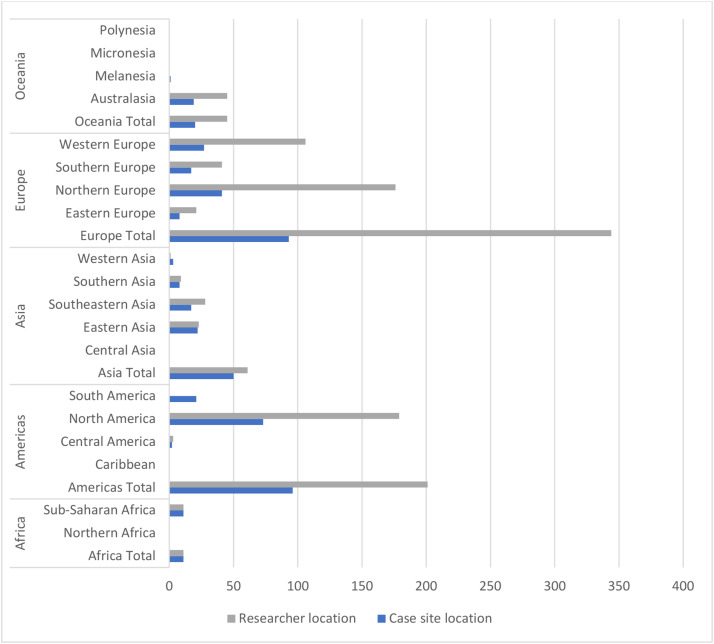

1. [Download : Download high-res image (193KB)](https://ars.els-cdn.com/content/image/1-s2.0-S0921800920309654-gr4_lrg.jpg)
2. [Download : Download full-size image](https://ars.els-cdn.com/content/image/1-s2.0-S0921800920309654-gr4.jpg)

Fig. 4. Number of articles for case site location and researcher location by world region and subregion.

### 4.1. Discussion

The bibliometric analyses highlight four notable Q-method publication trends. First, the co-authorship analysis (Fig. 3) demonstrates that, while numerous small research clusters use Q-method, there is little evidence of collaboration between groups. Furthermore, only 16.8% of authors in our analysis had more than one published Q-method paper in the review corpus, suggesting a further lack of collaboration between more and less experienced Q-method users. These trends, combined with the dearth of recent publications in both the most-cited primary sources (Table 1) and the most-cited corpus publications (Table 2), indicate that the most up-to-date knowledge on Q-method research is not being widely circulated within the broader population of socio-environmental researchers using Q-method.

Second, the results demonstrate high levels of geographic unevenness between Global South and Global North countries. Global South countries and institutions are disproportionately under-represented, both in terms of the researchers conducting Q-method studies and as research case study sites (Fig. 4). One explanation for this disparity relates to uneven access to resources such as research funding or institutional influence, which tend to be more concentrated in Global North countries and institutions. Furthermore, language barriers may incentivize researchers to conduct research in their home country or publish in their own languages. This may deepen existing disparities, as researchers with lower foreign language fluency may be less likely to publish in international and English-language journals. While the results indicate a potential trend of increasing researchers over time based in Southeastern Asia (*n* = 28), Eastern Asia (*n* = 23), Sub-Saharan Africa (*n* = 11), and Southern Asia (*n* = 9), additional structural barriers (*e.g.* limited grant funding opportunities, lack of access to publications behind journal paywalls, lack of access to Q-method software in non-English formats) may continue to limit Global South researchers' ability to conduct and publish Q-method research.

Fourth, the absolute numbers and rate of published socio-environmental Q-method studies have increased between 2000 and 2018. This does not indicate increased prevalence of Q-method use as a percentage of published socio-environmental research. However, when viewed against the other trends discussed above, the increase in Q-method publications highlights a need for systematically examining the strengths and weaknesses of this body of literature to aid future Q-method researchers and avoid reproducing gaps in research design, analysis, and reporting.

Together, these trends illustrate a relative lack of communication between different research clusters, institutions, and disciplines using Q-method as total publication numbers increase. These findings contextualize the highly variable Q-method practices and reporting strategies used across the socio-environmental Q-method literature discussed in the following section. We argue that this heterogeneity, coupled with limited collaboration across geographic and disciplinary lines, further restrict the ability for Q-method to move beyond a small group of researchers.

## 5. Q-method application results

Although Q-method protocol is relatively codified, its implementation offers considerable scope for interpretation and discretion to researchers. Such variability may be partially due to the subjective decisions required by researchers throughout its iterative stages. In this section, we discuss Q-method application, analysis, and reporting practices for participant selection, concourse and Q-set development, Q-sort implementation, and factor analysis across the analyzed studies. We find that Q-method research and reporting practices are heterogeneous across the publication corpus, with a high percentage of papers that do not include enough information to adequately determine the researchers' methodological practices or rationale.

### 5.1. Participants (P-set)

The *p-set*, or participant pool, is purposively selected by researchers. Researchers strategically sample participants who are likely to express viewpoints relevant to the research question. Often, researchers aim to sample participants to provide the broadest diversity of opinions on their topic of study. Because Q-method studies are not generalizable to the broader population, a much smaller p-set is needed than for conventional factor analysis; large p-sets are not necessary for robust analysis because participants act as *variables* rather than items (Brown, 1980). In fact, some researchers view large p-sets as detracting from Q-study design. One general guideline is to include fewer participants than study Q-set items (Watts and Stenner, 2012); another is to aim for between 4 and 6 participants to “define” each perspective (Webler et al., 2009).

The total p-set across the corpus ranges from 7 to 386, with an average of 41.6 participants and a mode of 24 (Fig. 5; see S1·C for detailed p-set data). 16 p-sets contain over 100 participants. The most common methods of identifying and selecting participants are purposive sampling (*n* = 169), snowball sampling (*n* = 37), and random selection (*n* = 32). 21 papers combine two selection methods, with the most common pairing being purposive and snowball sampling (*n* = 17). Nearly 15% of papers in our sample do not provide enough detail to determine their method of p-set selection (*n* = 40).

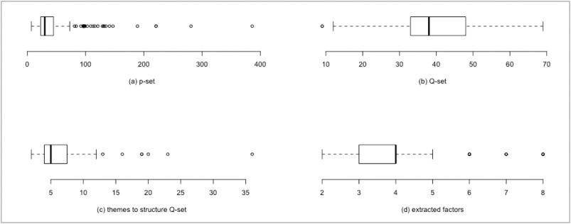

1. [Download : Download high-res image (83KB)](https://ars.els-cdn.com/content/image/1-s2.0-S0921800920309654-gr5_lrg.jpg)
2. [Download : Download full-size image](https://ars.els-cdn.com/content/image/1-s2.0-S0921800920309654-gr5.jpg)

Fig. 5. Range and average *n* for: (a) p-set; (b) Q-set, (c) themes to structure Q-set, and (d) extracted factors.

The 84 remaining papers (30.3%) either do not have a method to organize stakeholder inclusion criteria (*n* = 52), or such criteria is not specified (n = 32). For papers that specify one or more methods of organizing stakeholder inclusion, the primary means are by occupation and/or institutional affiliation (*n* = 78); geographic location (*n* = 39); demographics such as gender, socio-economic status, and/or educational status (*n* = 36); role in decision-making processes (*n* = 34); and participation in a specific program or event (*n* = 24).

### 5.2. Concourse and Q-set development

Researchers generate the *concourse*, a selection of subjective statements representing the breadth of the broader domain of subjectivity under study, often sampled from interviews, media reports, or scholarly literature. The *Q-set* – a smaller, representative set of statements – is drawn from the concourse, using methods such as a selection matrix (McKeown and Thomas, 2013), *a priori* themes drawn from existing literature, and inductive “theming” (Robbins and Krueger, 2000) to ensure representative coverage. The final Q-set should represent the breadth and depth of the concourse and, by extension, the subjective domain encompassed by the study. Small Q-sets may present inadequate topical coverage, but overly large numbers may be difficult for participants to sort in a timely way (Watts and Stenner, 2012).

Q-set size varies widely between studies. The number of Q-set items ranged from 9 to 69, with an average of 39.7 items and a mode of 36 (Fig. 5; see S1.D for detailed concourse/Q-set data).

Production of the concourse was narrowly considered among the review corpus. Nearly half of the corpus use only one source of information for the concourse. Document review (media reports, scientific literature, public policy review comments, policy documents, press releases, and other printed or digital materials) is the most common approach, and is the only concourse source for 60 studies. This is striking considering claims in the Q-method literature suggesting the need for “naturalistic” concourse development by prioritizing interviews with people heavily involved in the core issues comprising the domain (McKeown and Thomas, 2013). However, increased use of secondary sources may reflect changes in the nature and quality of data collection rather than inherently poor practice. We find the depth of researchers' justifications for their source material more valuable for gauging study robustness than focusing on source type alone.

Overall, the naturalistic approach is represented by nearly 60% of the corpus (*n* = 162) that use interviews, focus groups, workshops, or questionnaires in concourse production, with 43 using interviews as the only source of concourse material. The corpus varies wildly in terms of the detail authors provided on the naturalistic sources used for developing the concourse, with some detailing the procedures used to elicit statements from participants in interviews or workshops. However, several studies only list “interviews” as the source of concourse material, offering little information on how interviews are conducted, with which type of domain stakeholder, and how responses are analyzed.

Approximately one-third of the corpus use two types of materials for the concourse, mainly document review and interviews (*n* = 76). In 36 studies, authors use three concourse items, combining such sources as documents review, interviews, focus groups, workshops, and surveys. Among the least-used concourse sources were workshops and focus groups (*n* = 28), surveys or questionnaires (*n* = 11), and photographs (n = 11). Studies with no defined data source for concourse generation comprise 10% of the corpus (n = 28). This is a troubling finding considering how much space has been devoted in descriptions of Q-method practice to concourse development as a fundamental stage of rigorous Q-method application.

Themes are generally used to guide the selection of statements from the concourse in order to generate a representative and balanced Q-set, or what McKeown and Thomas (2013) call “structured” Q-set design. Structured samples are systematically constructed using explicit criteria to ensure comprehensive and representative coverage to the greatest degree possible. 193 of the papers (69.7%) report using themes or foci to structure statement selection for the final Q-set. Over 30% (*n* = 84) of papers use unstructured sampling or contain insufficient information to determine the mode of Q-set construction. Of the papers using structured sampling methods, 18 papers do not note the number of themes. For the remaining 175 studies, the number of themes ranges between 2 (minimum) and 36 (maximum), with an average of 5.97 and a mode of 4 (Fig. 5).

*A priori* themes are created outside the context of the concourse – that is to say, they are constructed by the author or from another source, then applied to the concourse to deductively structure the Q-set. Of the 85 studies using *a priori* themes, the majority are derived from scholarly literature (*n* = 61), followed by non-scholarly sources such as white papers, reports, or management tools (*n* = 11). The remaining 12 papers contain enough information to determine that categories are *a priori*, but of unknown provenance.

48 papers describe an inductive approach to generate themes. Inductive approaches refer to generating themes from concourse statements to structure the Q-set, rather than imposing an external organizational structure as with *a priori* themes. 20 papers describe using specific tools to structure their process and/or ensure methodological rigor, including grounded theory, *i.e.* systematic coding to identify repeated ideas (n = 6); qualitative coding software (*n* = 5)<sup>3</sup>; factorial design (n = 5); or additional layers of validation such as inter-coder reliability, external expert feedback, or pilot testing (n = 11). The remaining 27 papers contain enough information to determine that themes are produced inductively but lack detail on how this is accomplished, albeit with significant variability concerning the length and depth of authors' descriptions.

35 studies use factorial design as a structured sampling method to create Q-sets. This approach is generally operationalized using a sampling matrix to ensure representative selection of statements across diverse themes, valence (positive *vs* negative perspectives), or other variables (McKeown and Thomas, 2013). Factorial design can be used with both *a priori* and inductive approaches; however, the majority of papers in this sub-group (*n* = 24) used *a priori* themes, followed by inductive themes (n = 5), unclear provenance of themes (n = 5), and mixture of *a priori* and inductive (n = 1).

### 5.3. Conducting Q-sorts

During data collection, study participants complete *Q-sorts* by rank-ordering Q-set statements onto a forced choice distribution board. The poles of this board typically correspond with “most like your view” and “most unlike your view.” Participants complete the Q-sort in response to the provided *condition of instruction* – a research question which participants answer by sorting the provided Q-set items. Q-sorts may be conducted in-person or remotely, such as by using dedicated software packages. Some researchers conduct follow-up interviews or questionnaires after the Q-sorts to elicit further detail about participants' interpretations of various statements. The majority of papers report administering in-person Q-sorts, with some conducted online (*n* = 26). For online Q-sorts (S1.E), Flash Q is the most common software application (*n* = 13), followed by Q-Assessor (n = 5), Q-Sortware (*n* = 4), POETQ (n = 2), and Web Q (n = 2).

### 5.4. Analysis and interpretation

Researchers typically analyze Q-sort data using a dedicated software package (PQMethod, PCQ, Ken-Q/KADE, and R are some examples). Using either Principal Component Analysis (PCA) or centroid factor analysis, the software extracts unrotated factors which represent shared subjective perspectives among study participants. Researchers conventionally rotate factors using Varimax orthogonal or manual rotation to maximize explained variance. Researchers interpret their final factor analysis using *factor arrays*: factor estimates which weight and average all Q-sorts associated with that factor. The factor arrays appear as completed Q-sorts, each representing an idealized worldview. Factor arrays may be supplemented by qualitative data from accompanying questionnaires or interviews, if conducted as part of the study.

The final number of extracted factors in our corpus ranges from 2 to 8, with an average of 3.73 and a mode of 3 (Fig. 5; see S1·F for detailed analysis and interpretation data). PQMethod is the most common software used for analysis (*n* = 204), with some studies using R (*n* = 12), SPSS (n = 12), and PCQ (*n* = 8) software applications.<sup>4</sup> 44 papers do not indicate what software was used to complete the analysis. We attend to three areas of Q-method analysis in this section: factor creation criteria, confounding and insignificant Q-sorts, and consensus between factors.

#### 5.4.1. Factor creation criteria

The factors produced in a Q-method study comprise its core findings, with researchers interpreting these factors as shared social perspectives among the study p-set. It is widely acknowledged that there is no objectively correct number of factors in Q-method research. In theory, there are an infinite number of possible factor solutions. Researchers use a variety of criteria to select the most appropriate and meaningful number of factors under local circumstances (Huaranca et al., 2019). Measures researchers may consider when extracting factors include simplicity (fewer factors generally preferred), clarity (optimizing number of significantly-loading Q-sorts, while decreasing number of insignificant or confounded Q-sorts), distinctness (low similarity between factors), and stability (sorts are clustered together with different factor solutions) (Webler et al., 2009).

Close to a third of the study sample (*n* = 86) did not name specific criteria used to define the number of factors. Of the remaining 191 studies, the most commonly cited criteria include the Kaiser-Guttman criterion, or eigenvalues greater than 1.0 (*n* = 123); the amount of variance explained by the factor solution (*n* = 103); Humphrey's Rule I (*n* = 69); subjective interpretation (*n* = 55); and scree plot analysis (*n* = 31) (Table 3).

Table 3. Commonly-used factor extraction criteria with definitions.

| Criterion | Definition |
| --- | --- |
| Humphrey's Rule I | Factor has at least 2 significant loadings |
| Humphrey's Rule II | Cross product of 2 highest loadings exceeds 2× the standard error |
| Kaiser-Guttman criterion | Eigenvalue >1 |
| Scree plot analysis | Eigenvalues plotted on line graph to identify where slope changes, indicating number of factors |
| Subjective meaning | Perspective encompassed by factor is meaningful and theoretically important |
| Variance | Solution counts for over 50% of total variance; each factor accounts for at least 10% of total variance |

The number of criteria used in different studies to make a decision on factor extraction vary widely. Of the papers that describe the criteria used to select the number of factors (*n* = 191), more than 90% (*n* = 173) mention at least one of the following four criteria: (a) the Kaiser-Guttman criterion; (b) explained variance; (c) Humphrey's rule I; and (d) a subjective interpretation of the meaning of the different factors in the context of the study.

Extracted factors are conventionally rotated to maximize the explained variance between factors (but see Nost et al., 2019 on leaving factors unrotated). Although most studies in our analysis use Varimax orthogonal rotation, some papers also use judgmental hand rotation to more clearly separate factors (*n* = 31).

#### 5.4.2. Confounded and insignificant Q-sorts

When selecting final factors for extraction, it is likely some participants will not load significantly onto any factor (*insignificant*) or will load significantly onto more than one factor (*confounded*). Conventionally, Q-methodology researchers seek to limit the number of insignificant and confounded participants in their extracted factors.

Less than a fifth of papers discuss the presence of insignificant (n = 55) or confounded (*n* = 54) Q-sorts. A further 25 studies do not explicitly mention either insignificant or confounded Q-sorts, but close examination of the study results reveals their presence. 15 studies explicitly report no confounded and/or insignificant Q-sorts after factor analysis. Seven studies note they are present but do not explain whether they are excluded from the final factor analysis.

For the 55 papers that report insignificant Q-sorts, 30 studies described the authors' justification for including or excluding insignificant loaders from analysis. The majority of such papers describe excluding insignificant Q-sorts (*n* = 27). In some cases, researchers reduce the total number by raising the significance level used to determine factor loadings (n = 1); others use their presence as a criterion for factor selection (n = 2). Only three researchers included insignificant Q-sorts in their analysis, describing them as potentially emergent or relevant minority viewpoints.

For the 54 papers mentioning confounded Q-sorts, 41 studies provide an explanation for including or excluding them from analysis. Conventionally, confounded sorts are excluded from analysis in Q-method studies, in line with Webler et al.'s (2009) *clarity* criterion (Section 5.4.1). Of the 17 papers that describe excluding confounded Q-sorts, some researchers instead raise the significance level used to determine factor loadings, thereby reducing the number of confounded Q-sorts (n = 3). Another approach is to assign confounded sorts to their highest loading factor (n = 3). However, some papers (*n* = 24) instead include confounded sorts in the analysis and interpret them as a valuable source of data in their own right, *i.e.* by undermining pre-determined assumptions about the beliefs of individuals within a particular stakeholder group.

#### 5.4.3. Consensus between factors

Identifying consensus statements, or Q-set statements ranked similarly across all factors during factor analysis, highlights agreement between diverse perspectives, which can be interpreted as potential points of compromise in environmental decision-making. Q-method can therefore be valuable for negotiating seemingly intractable differences on contested environmental issues (Fast, 2015). Many studies in our sample examine areas of agreement between perspectives as well as differences. More than 60% (*n* = 167) of the review corpus provide some information on consensus between factors. The amount and depth of discussion on inter-factor consensus varies greatly between papers. In some cases, analysis is limited to the detection, or noting the lack, of consensus statements. The remaining papers discuss the implications of consensus statements in greater detail, ranging from consensus findings in tables or charts, devoting entire sections to consensus, or focusing on finding consensus as a central research concern.

## 6. Gaps and limitations in Q-method research

Recent Q-method papers studying socio-environmental sustainability demonstrate procedures that could be considered as “standardized,” but which are not implemented in a standard way. Researchers' subjective knowledge, and their considerable scope for interpretation and discretion throughout the Q-method process, means some variability is to be expected. While diversity and innovation can be “healthy” for methodological rigor (Eden et al., 2005), we find the degree of heterogeneity in the corpus surprising.

Far more concerning than the presence of variable Q-method practices is the infrequency with which such practices are fully described and/or justified by the authors. The results show that researchers' decisions for Q-method design, practices, analysis and interpretation are frequently under-reported. In such cases, authors provide insufficient detail regarding their research choices, limiting readers' abilities to adequately understand and replicate researchers' decision-making processes. Table 4 summarizes the major gaps identified across our study corpus. We present four potential explanations for these pervasive gaps in Q-method practice and reporting.

Table 4. Reporting gaps in Q-methodology review corpus.

| Q-method phase | Reporting gap description | *N* | Percentage |
| --- | --- | --- | --- |
| P-set | Method of p-set selection not described | 40 | 14.4% |
|  | Stakeholder inclusion / organization criteria not described | 84 | 30.3% |
| Concourse/Q-set development | Source of concourse / Q-set items not described | 28 | 10.1% |
|  | Method of Q-set creation from concourse not described | 84 | 30.3% |
|  | No discussion of how themes were produced and/or applied | 93 | 33.6% |
|  | Does not estimate salience of themes and/or statements (*i.e.* whether participants agree they are important) | 274 | 98.9% |
| Analysis and interpretation | Q-method analytical software used not mentioned | 44 | 15.9% |
|  | Factor extraction criteria not described | 86 | 31% |
|  | No d ddata on insignificant Q-sorts | 222 | 80.1% |
|  | No data on confounded Q-sorts | 223 | 80.5% |
|  | No data on consensus between factors | 110 | 39.7% |
|  | No discussion on study limitations | 198 | 71.5% |

First, the lack of sufficient reporting could result from length restrictions in journals that may severely limit full descriptions of methodological procedures. Furthermore, there continues to be a perceived need to describe Q-method as a little-known methodology in socio-environmental science. Many authors use valuable space describing Q-method steps in general terms, rather than focusing on their specific applications. The trend of increasing Q-method publications over the last decade suggests that Q-method is relatively well-known in socio-environmental research and that authors need not recount its generic steps at the expense of their own procedure. As noted in the bibliometric analysis (Section 4), the average number of publications has increased from 4 per year (2000–2009) to 26 per year (2010–2018). Our sample includes a total of 141 distinct journals with at least one published Q-method study, with 44 publishing two or more. Researchers are less likely to need to describe Q-method protocol and justify its use if submitting a journal with prior Q-method studies, instead reserving detailed summaries when introducing Q-method to journals or disciplines with lower familiarity.

Second, many researchers have published only one paper using Q-method. This trend might play a role in the persistence of incomplete reporting and unsupported choices relating to study design, analysis, and interpretation decisions. The co-authorship analysis (Section 4) shows only 111 out of 662 authors, or 16.8%, had published more than one paper in our sample. While this estimate may be low since some publications did not meet our inclusion criteria, it is unlikely that the majority of authors have multiple Q-method publications. This finding indicates that researchers are not developing a deeper knowledge or understanding about Q-method, and may explain why many papers include detailed Q-method protocol descriptions, as noted above. First-time Q-method use is not an inherent problem, nor does it preclude producing high-quality Q-method research. However, it does heighten the potential for reproducing weak study design, analysis, or interpretation practices, as well as reporting gaps.

Third, and relatedly, first-time Q-method users may be drawing primarily on a relatively small corpus of papers with higher citation counts as key sources to inform their understanding and use of Q-method. As noted in Section 4, four of the most-cited primary Q-method sources were published before 2000, and only one after 2010 (Table 1). Moreover, only seven of the 22 most-cited case studies in our corpus were published after 2010, and none after 2014, indicating their relative prominence in the Q-method socio-environmental literature (Table 2). While many of these papers demonstrate strengths in Q-method practice or theoretical/disciplinary relevance, several have significant weaknesses in their study design, analysis and interpretation choices, or in their reporting and justification. These limitations may be duplicated by first-time Q-method users who are less familiar with the method, particularly if not collaborating with more experienced Q-method users, and thus unlikely to recognize shortcomings or to be familiar with up-to-date methodological interventions and practices.

Fourth, the lack of collaboration across Q-method research groups, combined with lower citations for primary sources and studies published since 2010 (especially the last five years), suggests that common practices and innovative solutions are not being widely exchanged. Papers published more recently will, of course, be less frequently cited than earlier studies. However, first-time Q-method users may be less likely to find such papers, especially if they are focusing on case studies in their discipline, topic of study, or case site area. Such researchers are less likely to be looking for or aware of newer papers which employ innovative approaches or address previously-identified limitations within the broader body of socio-environmental Q-method research. As noted in the co-authorship analysis (Section 4), there is a relatively high number of disparate research groups using Q-method. However, our analysis indicates low levels of collaboration across these research clusters. Increased collaboration within and across such groups, with experienced researchers work with first-time Q-method users, could address some of these limitations.

The wide variety of research practices within Q-method socio-environmental research, which this analysis catalogues, can be attributed to a combination of the trends outlined above. However, the heterogeneity of approaches discussed in this paper also encompasses examples of papers demonstrating best practices for Q-method research. In the following section, we summarize these best practices and discuss potential solutions for addressing gaps in the Q-method esocio-environmental literature and associated barriers limiting Q-method adoption by first-time users.

## 7. Best practices in Q-methodology research

Table 5. Best practices in Q-methodology review corpus.

| Research phase | Best practice description | Exemplar papers |
| --- | --- | --- |
| P-set | Describe p-set identification, selection, and sampling strategy | Armatas et al. (2014) Peters and Ward (2017) Zabala et al. (2017) |
|  | If participants are categorized, describe how categories are derived and why they are used | Fry et al. (2017) Restrepo-Osorio and Brown (2018) Vela-Almeida et al. (2018) |
| Concourse/Q-set development | Describe types and number of sources used to sample concourse / Q-set items | Mazur and Asah (2013) Rodríguez-Piñeros and Mayett-Moreno (2014) Pelenur (2018) |
|  | Describe strategy for identifying and sampling concourse items | Gruber (2011) Falk-Petersen (2014) Beckham Hooff et al. (2017) |
|  | Use multiple sources to ensure representative coverage in study concourse / Q-set | Cotton (2015) Díaz et al. (2017) Amaruzaman et al. (2017) |
|  | Provide details on interview / survey questions and methods, if using | Jaung et al. (2016) Frate and Brannstrom (2017) Rodríguez-Piñeros et al. (2018) |
|  | Describe strategy for sampling Q-set items from concourse | Forouzani et al. (2013) Cotton and Mahroos-Alsaiari (2015) Naspetti et al. (2016) |
|  | Estimate salience for themes and/or statements | Webler et al. (2001) Tuler and Webler (2009) Chapman et al. (2015) |
| Analysis and interpretation | Explain decision-making process and criteria used for factor extraction | Cavanagh et al. (2016) Pirard et al. (2016) Farrell et al. (2017) |
|  | Triangulate between multiple criteria when deciding how many factors to extract | Sala et al. (2015) Benitez-Capistros et al. (2016) Gannon and Hulme (2018) |
|  | Compare multiple solutions to judge stability of the extracted factors | Clare et al. (2013) Späth (2018) Walder and Kantelhardt (2018) |
|  | Show analysis to participants for additional layer of verification and feedback | Strickert et al. (2016) Smith and Bond (2018) Zanoli et al. (2018) |
|  | Describe whether insignificant / confounded Q-sorts are present, and if so, explain if / why they are excluded in further analysis | Setiawan and Cuppen (2013) Hugé et al. (2016) Niedziałkowski et al. (2018) |
|  | Analyze insignificant / confounded Q-sorts in analysis as valuable data sources | Asah et al. (2012a) Amick et al. (2015) Bischoff-Mattson et al. (2018) |
|  | Discuss whether analysis identifies consensus statements across factors | Asah et al. (2012b) Bauer (2018) Weitzman and Bailey (2018) |
| Publication practices | Include clear visuals (figures, tables, *etc.*) that add value to the analysis and are easily interpreted | Hermans et al., 2012 Payne and Shepardon (2015) Díaz and van Vliet (2018) |
|  | Provide transparency regarding study limitations | Hagan and Williams (2016) Hobson and Niemeyer (2011) Palomo-Campesino et al. (2018) |

For a checklist of suggested Q-method best practices and reporting guidelines, see S2.

Second, we recommend authors make greater use of supplements and appendices to include relevant information without inflating article length or displacing other important information. Many papers contain descriptions of Q-method history and protocol that may not necessary, especially in journals with previously published Q-method articles. While closer attention to Q-method fundamentals is warranted, journal word counts may restrict space for extended discussion on study design and data. Likewise, limited disciplinary exposure to Q-method, publishing in journals with few prior Q-method articles, or responding to reviewer comments for more detail may require longer methodological descriptions. Detailed descriptions of Q-method protocol and study design beyond that required to support the paper findings and arguments can be instead published as supplementary documents.

Relatedly, Q-method papers frequently incorporate tables summarizing study materials and data. Many journals include such tables and figures towards the word count. Authors should prioritize visualizations in the main text that directly support their analysis and are necessary to validate their arguments. Publishing additional study data in a supplement or appendix makes it available for readers while keeping articles concise. In many papers from our sample, authors publish their entire Q-set in a table or include illustrations of Q-sort boards. Such examples may be more appropriately published in the supplementary materials.

Another approach to provide more detailed analysis is to publish a series of related and interlocking, yet distinct, articles from the same dataset. This allows researchers to delve into aspects of their Q-studies in more depth. For example, Jepson et al. (2012) focus their analysis on the consensus statements from an earlier study examining perceptions of wind farming in West Texas (Brannstrom et al., 2011). Another cluster of papers (Cuppen et al., 2010; Cuppen, 2012a, Cuppen, 2012b; Ligtvoet et al., 2016) integrate Q-method within multiple stages of constructive conflict methodology (CCM), using Q-method to select participants for stakeholder dialogues, evaluate learning before and after stakeholder dialogues, and summarize CCM results (see also Armatas et al., 2014, Armatas et al., 2018; Spruijt et al., 2013, Spruijt et al., 2016).

Fourth, and related to the previous recommendation, is for Q-method users to develop collaborative relationships, particularly between first-time and experienced users and across disciplinary divisions to reduce potential knowledge and reporting gaps. In today's rapidly shifting academic and funding markets, greater emphasis is being placed on collaborative and multi-disciplinary research models. Journals publishing on sustainability and socio-environmental topics are frequently sites of interdisciplinary enquiry. Furthermore, Q-method provides an arrangement for researchers trained in both quantitative and qualitative methods to collaborate in a structured way. Q-method can provide a useful platform for larger-scale research projects by organizing data collection of Q-sorts alongside other data. In so doing, researchers can develop inter-related databases by incorporating Q-sorts with interview transcripts, content analysis, survey results, GIS maps and visualizations, and more. Q-method results may also act as pilot studies to ground and justify future proposed research. For example, some papers build on prior Q-studies, using models or large-n surveys to empirically test the generalizability of Q-method results (Baur et al., 2014; Rastogi et al., 2013; Song and Ko, 2017).

Lastly, researchers should ensure that Q-method is an appropriate methodological approach for answering their research question. Q-method's relatively rapid growth in terms of absolute publication numbers, and the concurrent publication of review articles such as this (see also Mukherjee et al., 2018; Zabala et al., 2018), are likely to raise its visibility among previously unfamiliar researchers. For studies researching stakeholder perspectives, Q-method offers a replicable, structured, and empirically rich way to answer research questions and include stakeholders throughout the research process.

Together, our recommendations indicate some methods for researchers to address the identified limitations in the socio-environmental Q-method literature, reduce barriers for first-time Q-method users, and retain the ability to experiment methodologically. Attending to the major gaps identified from our analysis will strengthen Q-method research in the environmental social sciences, while also addressing some of the structural issues limiting the diffusion of shared, best practices among socio-environmental researchers using Q-method.

## 8. Conclusion

The systematic review outlined in this paper summarizes new findings on the trends, gaps, and best practices of Q-method socio-environmental research. Warranted by the lack of a systematic review of this literature, our analysis supplies much-needed descriptive data on research and publishing trends in the Q-method community, particularly for those studying perspectives on sustainability, natural resource management, and human-environment interactions. Our review demonstrates high levels of variability on Q-method practice and reporting. These data, combined with our bibliometric analysis, indicate that up-to-date knowledge on Q-method practices and innovations are not being exchanged to the widest degree possible, in spite of several examples that clearly describe both standard and innovative procedures.

The goal of this study was to identify major gaps within the systematic review publication corpus and recommend best practices for Q-method users to address these limitations and continue improving the quality of Q-method research design, practices, and reporting. However, our analysis is constrained by some limitations. First, the scope of our review is limited to the field of sustainable natural resource management. As a result, our review excludes publications relating to the topic of sustainability writ large (*e.g.* public perceptions of climate change) that do not relate directly to natural resource management efforts. Furthermore, our sample only includes studies published in English between 2000 and 2018. As a result, we were not able to include non-English language publications or those published from 2019 onward. Future reviews of Q-method literature can address these limitations.

While our review attends to a major gap by assessing the current state of Q-method research in the socio-environmental sciences, additional research is necessary to more fully understand the trends, shortcomings, and innovative procedures within Q-method sustainability scholarship. In addition to updating the review parameters used in our study, future research directions include reviewing the Q-method literature for narrower topics or disciplines within environmental social sciences. Most importantly, we hope to see future Q-method users adopting the best practices drawn from the papers reviewed here, as socio-environmental researchers continue using Q-methodology to understand and address stakeholder perspectives to support sustainable natural resource governance.

## Declaration of Competing Interest

The authors have no conflicts of interest to disclose.

## Acknowledgements

We would like to thank Texas A&M University and the Office of the President's Excellence Grants, United States for financial support for the project “Pathways to Urban Water Security: Desalination and Water Reuse in the 21<sup>st</sup> Century.” The authors also acknowledge support from the National Research Council of Argentina (CONICET) and the National University of Salta (UNSa), Argentina. We would also like to thank the comments of the *Ecological Economics* editors, two anonymous reviewers, and Dr. Amanda Fencl, which have greatly improved this paper.

## Appendix A. Supplementary data

[Download : Download Word document (1MB)](https://ars.els-cdn.com/content/image/1-s2.0-S0921800920309654-mmc1.docx)

Supplementary material

## References

**Amaruzaman et al., 2017**

S. Amaruzaman, B. Leimona, N. van Meine, B. Lusiana**Discourses on the performance gap of agriculture in a green economy: a Q-methodology study in Indonesia**

Int. J. Biodivers. Sci. Ecosyst. Serv. Manag., 13 (2017), pp. 233-247, 10.1080/21513732.2017.1331264

[CrossRef](https://doi.org/10.1080/21513732.2017.1331264)[View Record in Scopus](https://www.scopus.com/inward/record.url?eid=2-s2.0-85045841576&partnerID=10&rel=R3.0.0)Google Scholar

**Amick et al., 2015**

K. Amick, D. Clark, R.K. Brook**Stakeholder perspectives on chronic wasting disease risk and management on the Canadian prairies**

Hum. Dimens. Wildl., 20 (2015), pp. 408-424, 10.1080/10871209.2015.1046095

[CrossRef](https://doi.org/10.1080/10871209.2015.1046095)[View Record in Scopus](https://www.scopus.com/inward/record.url?eid=2-s2.0-84942368246&partnerID=10&rel=R3.0.0)Google Scholar

**Armatas et al., 2014**

C.A. Armatas, T.J. Venn, A.E. Watson**Applying Q-methodology to select and define attributes for non-market valuation: a case study from Northwest Wyoming, United States**

Ecol. Econ., 107 (2014), pp. 447-456, 10.1016/j.ecolecon.2014.09.010

[Article](https://www.sciencedirect.com/science/article/pii/S0921800914002808)[Download PDF](https://www.sciencedirect.com/science/article/pii/S0921800914002808/pdfft?md5=f514809bb18b07e981010d7a718f028f&pid=1-s2.0-S0921800914002808-main.pdf)[View Record in Scopus](https://www.scopus.com/inward/record.url?eid=2-s2.0-84907560555&partnerID=10&rel=R3.0.0)Google Scholar

**Armatas et al., 2018**

C.A. Armatas, R.M. Campbell, A.E. Watson, Borrie, T. William, N. Christensen, T.J. Venn**An integrated approach to valuation and tradeoff analysis of ecosystem services for national forest decision-making**

Ecosyst. Serv., 33 (2018), pp. 1-18, 10.1016/j.ecoser.2018.07.007

[Article](https://www.sciencedirect.com/science/article/pii/S2212041617307477)[Download PDF](https://www.sciencedirect.com/science/article/pii/S2212041617307477/pdfft?md5=325127ba32ed6bb1baa966db6b0a338f&pid=1-s2.0-S2212041617307477-main.pdf)[View Record in Scopus](https://www.scopus.com/inward/record.url?eid=2-s2.0-85050109779&partnerID=10&rel=R3.0.0)Google Scholar

**Asah et al., 2012a**

S.T. Asah, D.N. Bengston, K. Wendt, L. DeVaney**Prognostic framing of stakeholders’ subjectivities: a case of all-terrain vehicle management on state public lands**

Environ. Manag., 49 (2012), pp. 192-206, 10.1007/s00267-011-9756-7

[CrossRef](https://doi.org/10.1007/s00267-011-9756-7)[View Record in Scopus](https://www.scopus.com/inward/record.url?eid=2-s2.0-84856696389&partnerID=10&rel=R3.0.0)[Google Scholar](https://scholar.google.com/scholar?q=Prognostic%20framing%20of%20stakeholders%20subjectivities:%20a%20case%20of%20all-terrain%20vehicle%20management%20on%20state%20public%20lands)

**Asah et al., 2012b**

S.T. Asah, D.N. Bengston, K. Wendt, K.C. Nelson**Diagnostic reframing of intractable environmental problems: case of a contested multiparty public land-use conflict**

J. Environ. Manag., 108 (2012), pp. 108-119, 10.1016/j.jenvman.2012.04.041

[Article](https://www.sciencedirect.com/science/article/pii/S0301479712002381)[Download PDF](https://www.sciencedirect.com/science/article/pii/S0301479712002381/pdfft?md5=6bb34945d8d1817b2487c571726a65ba&pid=1-s2.0-S0301479712002381-main.pdf)[View Record in Scopus](https://www.scopus.com/inward/record.url?eid=2-s2.0-84862258052&partnerID=10&rel=R3.0.0)Google Scholar

**Bacher et al., 2014**

K. Bacher, A. Gordoa, E. Mikkelsen**Stakeholders’ perceptions of marine fish farming in Catalonia (Spain): a Q-methodology approach**

Aquaculture, 424 (2014), pp. 78-85, 10.1016/j.aquaculture.2013.12.028

[Article](https://www.sciencedirect.com/science/article/pii/S0044848613006832)[Download PDF](https://www.sciencedirect.com/science/article/pii/S0044848613006832/pdfft?md5=edcbd84ecbf3e2649df76fc0fdac60f9&pid=1-s2.0-S0044848613006832-main.pdf)[View Record in Scopus](https://www.scopus.com/inward/record.url?eid=2-s2.0-84892644371&partnerID=10&rel=R3.0.0)[Google Scholar](https://scholar.google.com/scholar?q=Stakeholders%20perceptions%20of%20marine%20fish%20farming%20in%20Catalonia%20:%20a%20Q-methodology%20approach)

**Barry and Proops, 1999**

J. Barry, J. Proops**Seeking sustainability discourses with Q methodology**

Ecol. Econ., 28 (1999), pp. 337-345, 10.1016/S0921-8009(98)00053-6

[Article](https://www.sciencedirect.com/science/article/pii/S0921800998000536)[Download PDF](https://www.sciencedirect.com/science/article/pii/S0921800998000536/pdfft?md5=228b739d2cb42d0afd95350ed10487d8&pid=1-s2.0-S0921800998000536-main.pdf)[View Record in Scopus](https://www.scopus.com/inward/record.url?eid=2-s2.0-0033104173&partnerID=10&rel=R3.0.0)[Google Scholar](https://scholar.google.com/scholar_lookup?title=Seeking%20sustainability%20discourses%20with%20Q%20methodology&publication_year=1999&author=J.%20Barry&author=J.%20Proops)

**Bauer, 2018**

F. Bauer**Narratives of biorefinery innovation for the bioeconomy: conflict, consensus or confusion?**

Environ. Innovat. Soc. Transit., 28 (2018), pp. 96-107, 10.1016/j.eist.2018.01.005

[Article](https://www.sciencedirect.com/science/article/pii/S2210422417301302)[Download PDF](https://www.sciencedirect.com/science/article/pii/S2210422417301302/pdfft?md5=66dd5c2e6663ae8f1e80b76956879bd3&pid=1-s2.0-S2210422417301302-main.pdf)[View Record in Scopus](https://www.scopus.com/inward/record.url?eid=2-s2.0-85041557140&partnerID=10&rel=R3.0.0)[Google Scholar](https://scholar.google.com/scholar?q=Narratives%20of%20biorefinery%20innovation%20for%20the%20bioeconomy:%20conflict,%20consensus%20or%20confusion)

**Baur et al., 2014**

I. Baur, K. Liechti, C.R. Binder**Why do individuals behave differently in commons dilemmas? The case of alpine farmers using common property pastures in Grindelwald, Switzerland**

Int. J. Commons, 8 (2014), pp. 657-685, 10.18352/ijc.469

[View Record in Scopus](https://www.scopus.com/inward/record.url?eid=2-s2.0-84907010720&partnerID=10&rel=R3.0.0)Google Scholar

**Beckham Hooff et al., 2017**

S. Beckham Hooff, I. Botetzagias, A. Kizos**Seeing the wind (farm): applying Q-methodology to understand the public’s reception of the visuals around a wind farm development**

Environ. Commun., 11 (2017), pp. 700-722, 10.1080/17524032.2017.1292937

[CrossRef](https://doi.org/10.1080/17524032.2017.1292937)[View Record in Scopus](https://www.scopus.com/inward/record.url?eid=2-s2.0-85015230436&partnerID=10&rel=R3.0.0)[Google Scholar](https://scholar.google.com/scholar?q=Seeing%20the%20wind%20:%20applying%20Q-methodology%20to%20understand%20the%20publics%20reception%20of%20the%20visuals%20around%20a%20wind%20farm%20development)

**Beckner et al., 2019**

S. Beckner, W. Jepson, C. Brannstrom, J. Tracy**‘The San Antonio River Doesn’t start in San Antonio, it now starts in Burleson County’: stakeholder perspectives on a groundwater transfer project in Central Texas**

Soc. Nat. Resour., 32 (2019), pp. 1222-1238, 10.1080/08941920.2019.1648709

[CrossRef](https://doi.org/10.1080/08941920.2019.1648709)[View Record in Scopus](https://www.scopus.com/inward/record.url?eid=2-s2.0-85070517668&partnerID=10&rel=R3.0.0)Google Scholar

**Benitez-Capistros et al., 2016**

F. Benitez-Capistros, J. Hugé, F. Dahdouh-Guebas, N. Koedam**Exploring conservation discourses in the Galapagos Islands: a case study of the Galapagos giant tortoises**

Ambio, 45 (2016), pp. 706-724, 10.1007/s13280-016-0774-9

[CrossRef](https://doi.org/10.1007/s13280-016-0774-9)[View Record in Scopus](https://www.scopus.com/inward/record.url?eid=2-s2.0-84961620928&partnerID=10&rel=R3.0.0)Google Scholar

**Bischoff-Mattson et al., 2018**

Z. Bischoff-Mattson, A.H. Lynch, L. Joachim**Justice, science, or collaboration: divergent perspectives on indigenous cultural water in Australia’s Murray-Darling basin**

Water Policy, 20 (2018), pp. 235-251, 10.2166/wp.2018.145

[CrossRef](https://doi.org/10.2166/wp.2018.145)[Google Scholar](https://scholar.google.com/scholar?q=Justice,%20science,%20or%20collaboration:%20divergent%20perspectives%20on%20indigenous%20cultural%20water%20in%20Australias%20Murray-Darling%20basin)

**Bracken et al., 2016**

L. Bracken, E.A. Oughton, A. Donaldson, B. Cook, J. Forrester, C. Spray, S. Cinderby, D. Passmore, N. Bissett**Flood risk management, an approach to managing cross-border hazards**

Nat. Hazards, 82 (2016), pp. S217-S240, 10.1007/s11069-016-2284-2

Google Scholar

**Brannstrom, 2011**

C. Brannstrom**A Q-method analysis of environmental governance discourses in Brazil’s northeastern soy frontier**

Prof. Geogr., 63 (2011), pp. 531-549, 10.1080/00330124.2011.585081

[CrossRef](https://doi.org/10.1080/00330124.2011.585081)[View Record in Scopus](https://www.scopus.com/inward/record.url?eid=2-s2.0-80053254407&partnerID=10&rel=R3.0.0)[Google Scholar](https://scholar.google.com/scholar?q=A%20Q-method%20analysis%20of%20environmental%20governance%20discourses%20in%20Brazils%20northeastern%20soy%20frontier)

**Brannstrom et al., 2011**

C. Brannstrom, W. Jepson, N. Persons**Social perspectives on wind-power development in West Texas**

Ann. Assoc. Am. Geogr., 101 (2011), pp. 839-851

[CrossRef](https://doi.org/10.1080/00045608.2011.568871)[View Record in Scopus](https://www.scopus.com/inward/record.url?eid=2-s2.0-79958760590&partnerID=10&rel=R3.0.0)[Google Scholar](https://scholar.google.com/scholar_lookup?title=Social%20perspectives%20on%20wind-power%20development%20in%20West%20Texas&publication_year=2011&author=C.%20Brannstrom&author=W.%20Jepson&author=N.%20Persons)

**Brodt et al., 2006**

S. Brodt, K. Klonsky, L. Tourte**Farmer goals and management styles: implications for advancing biologically based agriculture**

Agric. Syst., 89 (2006), pp. 90-105, 10.1016/j.agsy.2005.08.005

[Article](https://www.sciencedirect.com/science/article/pii/S0308521X05001496)[Download PDF](https://www.sciencedirect.com/science/article/pii/S0308521X05001496/pdfft?md5=7f2192b117cf522a1e78a2b609e70559&pid=1-s2.0-S0308521X05001496-main.pdf)[View Record in Scopus](https://www.scopus.com/inward/record.url?eid=2-s2.0-33645776235&partnerID=10&rel=R3.0.0)Google Scholar

**Brown, 1980**

S. Brown**Political Subjectivity**

Yale University Press, New Haven, CT (1980)

[Google Scholar](https://scholar.google.com/scholar_lookup?title=Political%20Subjectivity&publication_year=1980&author=S.%20Brown)

**Brown et al., 2015**

S.R. Brown, S. Danielson, J. van Exel**Overly ambitious critics and the Medici effect: a reply to Kampen and Tamás**

Qual. Quant., 49 (2015), pp. 523-537, 10.1007/s11135-014-0007-x

[CrossRef](https://doi.org/10.1007/s11135-014-0007-x)[View Record in Scopus](https://www.scopus.com/inward/record.url?eid=2-s2.0-84894307981&partnerID=10&rel=R3.0.0)Google Scholar

**Carr and Liu, 2016**

L.M. Carr, D.Y. Liu**Measuring stakeholder perspectives on environmental and community stability in a tourism-dependent economy**

Int. J. Tour. Res., 18 (2016), pp. 620-632, 10.1002/jtr.2084

[CrossRef](https://doi.org/10.1002/jtr.2084)[View Record in Scopus](https://www.scopus.com/inward/record.url?eid=2-s2.0-84994059779&partnerID=10&rel=R3.0.0)Google Scholar

**Cavanagh et al., 2016**

R.D. Cavanagh, S.L. Hill, C.A. Knowland, S.M. Grant**Stakeholder perspectives on ecosystem-based management of the Antarctic krill fishery**

Mar. Policy, 68 (2016), pp. 205-211, 10.1016/j.marpol.2016.03.006

[Article](https://www.sciencedirect.com/science/article/pii/S0308597X16300872)[Download PDF](https://www.sciencedirect.com/science/article/pii/S0308597X16300872/pdfft?md5=73fc94f27f6f7b226fc4cd602d292cf0&pid=1-s2.0-S0308597X16300872-main.pdf)[View Record in Scopus](https://www.scopus.com/inward/record.url?eid=2-s2.0-84960461312&partnerID=10&rel=R3.0.0)Google Scholar

**Chapman et al., 2015**

R. Chapman, M. Tonts, P. Plummer**Exploring perceptions of the impacts of resource development: a Q-methodology study**

Extract. Indus. Soc., 2 (2015), pp. 540-551, 10.1016/j.exis.2015.04.008

[Article](https://www.sciencedirect.com/science/article/pii/S2214790X15000805)[Download PDF](https://www.sciencedirect.com/science/article/pii/S2214790X15000805/pdfft?md5=dd32e704d5c9cc6bf0942077b00d01b9&pid=1-s2.0-S2214790X15000805-main.pdf)[View Record in Scopus](https://www.scopus.com/inward/record.url?eid=2-s2.0-84938745282&partnerID=10&rel=R3.0.0)Google Scholar

**CitNetExplorer, 2020**

CitNetExplorer**Analyzing Citation Patterns in Scientific Literature [WWW Document]**

CitNetExplorer (2020)

URL

https://www.citnetexplorer.nl/

(accessed 5.15.20)

[Google Scholar](https://scholar.google.com/scholar?q=Analyzing%20Citation%20Patterns%20in%20Scientific%20Literature%20WWW%20Document)

**Clare et al., 2013**

S. Clare, N. Krogman, K.J. Caine**The “balance discourse”: a case study of power and wetland management**

Geoforum, 49 (2013), pp. 40-49, 10.1016/j.net.2018.07.002

[Article](https://www.sciencedirect.com/science/article/pii/S0016718513001231)[Download PDF](https://www.sciencedirect.com/science/article/pii/S0016718513001231/pdfft?md5=c7a5a5ba12120098efb68d97306748c8&pid=1-s2.0-S0016718513001231-main.pdf)[View Record in Scopus](https://www.scopus.com/inward/record.url?eid=2-s2.0-84984573422&partnerID=10&rel=R3.0.0)[Google Scholar](https://scholar.google.com/scholar?q=The%20balance%20discourse:%20a%20case%20study%20of%20power%20and%20wetland%20management)

**Clarke, 2002**

A.H. Clarke**Understanding sustainable development in the context of other emergent environmental perspectives**

Policy. Sci., 35 (2002), pp. 69-90, 10.1023/A:1016067819764

[View Record in Scopus](https://www.scopus.com/inward/record.url?eid=2-s2.0-0036332983&partnerID=10&rel=R3.0.0)[Google Scholar](https://scholar.google.com/scholar_lookup?title=Understanding%20sustainable%20development%20in%20the%20context%20of%20other%20emergent%20environmental%20perspectives&publication_year=2002&author=A.H.%20Clarke)

**Cotton, 2015**

M.D. Cotton**Stakeholder perspectives on shale gas fracking: a Q-method study of environmental discourses**

Environ. Plan. A, 47 (2015), pp. 1944-1962, 10.1177/0308518X15597134

[CrossRef](https://doi.org/10.1177/0308518X15597134)[Google Scholar](https://scholar.google.com/scholar_lookup?title=Stakeholder%20perspectives%20on%20shale%20gas%20fracking%3A%20a%20Q-method%20study%20of%20environmental%20discourses&publication_year=2015&author=M.D.%20Cotton)

**Cotton and Mahroos-Alsaiari, 2015**

M.D. Cotton, A.A. Mahroos-Alsaiari**Key actor perspectives on stakeholder engagement in Omani environmental impact assessment: an application of Q-methodology**

J. Environ. Plan. Manag., 58 (2015), pp. 91-112, 10.1080/09640568.2013.847822

[CrossRef](https://doi.org/10.1080/09640568.2013.847822)[View Record in Scopus](https://www.scopus.com/inward/record.url?eid=2-s2.0-84912014275&partnerID=10&rel=R3.0.0)Google Scholar

**Cuppen, 2012a**

E. Cuppen**A quasi-experimental evaluation of learning in a stakeholder dialogue on bio-energy**

Res. Policy, 41 (2012), pp. 624-637, 10.1016/j.respol.2011.12.006

[Article](https://www.sciencedirect.com/science/article/pii/S0048733311002289)[Download PDF](https://www.sciencedirect.com/science/article/pii/S0048733311002289/pdfft?md5=a58023d493c53e4fe50885fd1fb4fa29&pid=1-s2.0-S0048733311002289-main.pdf)[View Record in Scopus](https://www.scopus.com/inward/record.url?eid=2-s2.0-84857055912&partnerID=10&rel=R3.0.0)[Google Scholar](https://scholar.google.com/scholar_lookup?title=A%20quasi-experimental%20evaluation%20of%20learning%20in%20a%20stakeholder%20dialogue%20on%20bio-energy&publication_year=2012&author=E.%20Cuppen)

**Cuppen, 2012b**

E. Cuppen**Diversity and constructive conflict in stakeholder dialogue: considerations for design and methods**

[CrossRef](https://doi.org/10.1007/s11077-011-9141-7)[View Record in Scopus](https://www.scopus.com/inward/record.url?eid=2-s2.0-84857644370&partnerID=10&rel=R3.0.0)Google Scholar

**Cuppen et al., 2010**

E. Cuppen, S. Breukers, M. Hisschemöller, E. Bergsma**Q methodology to select participants for a stakeholder dialogue on energy options from biomass in the Netherlands**

Ecol. Econ., 69 (2010), pp. 579-591, 10.1016/j.ecolecon.2009.09.005

[Article](https://www.sciencedirect.com/science/article/pii/S0921800909003929)[Download PDF](https://www.sciencedirect.com/science/article/pii/S0921800909003929/pdfft?md5=593c3c9d35fc5e3e7c604a1636a8ce32&pid=1-s2.0-S0921800909003929-main.pdf)[View Record in Scopus](https://www.scopus.com/inward/record.url?eid=2-s2.0-72049123470&partnerID=10&rel=R3.0.0)Google Scholar

**Davies and Hodge, 2007**

B.B. Davies, I.D. Hodge**Exploring environmental perspectives in lowland agriculture: a Q methodology study in East Anglia, UK**

Ecol. Econ., 61 (2007), pp. 323-333, 10.1016/j.ecolecon.2006.03.002

[Article](https://www.sciencedirect.com/science/article/pii/S0921800906001327)[Download PDF](https://www.sciencedirect.com/science/article/pii/S0921800906001327/pdfft?md5=382305ca4f7a98a7afa84f9ca4973917&pid=1-s2.0-S0921800906001327-main.pdf)[View Record in Scopus](https://www.scopus.com/inward/record.url?eid=2-s2.0-33847358595&partnerID=10&rel=R3.0.0)Google Scholar

**Davies and Hodge, 2012**

B.B. Davies, I.D. Hodge**Shifting environmental perspectives in agriculture: repeated Q analysis and the stability of preference structures**

Ecol. Econ., 83 (2012), pp. 51-57, 10.1016/j.ecolecon.2012.08.013

[Article](https://www.sciencedirect.com/science/article/pii/S0921800912003291)[Download PDF](https://www.sciencedirect.com/science/article/pii/S0921800912003291/pdfft?md5=e61a26381d25c60493d018b0e8a876b7&pid=1-s2.0-S0921800912003291-main.pdf)[View Record in Scopus](https://www.scopus.com/inward/record.url?eid=2-s2.0-84868313220&partnerID=10&rel=R3.0.0)Google Scholar

**Díaz and van Vliet, 2018**

P. Díaz, O. van Vliet**Drivers and risks for renewable energy developments in mountain regions: a case of a pilot photovoltaic project in the Swiss Alps**

Energy Sustain. Soc., 8 (2018), p. 28, 10.1186/s13705-018-0168-x

[View Record in Scopus](https://www.scopus.com/inward/record.url?eid=2-s2.0-85045505672&partnerID=10&rel=R3.0.0)Google Scholar

**Díaz et al., 2017**

P. Díaz, C.E. Adler, A. Patt**Do stakeholders’ perspectives on renewable energy infrastructure pose a risk to energy policy implementation? A case of a hydropower plant in Switzerland**

Energy Policy, 108 (2017), pp. 21-28, 10.1016/j.enpol.2017.05.033

[Article](https://www.sciencedirect.com/science/article/pii/S0301421517303178)[Download PDF](https://www.sciencedirect.com/science/article/pii/S0301421517303178/pdfft?md5=7c6d473f5e72b889e8472358a33433bb&pid=1-s2.0-S0301421517303178-main.pdf)[View Record in Scopus](https://www.scopus.com/inward/record.url?eid=2-s2.0-85019736398&partnerID=10&rel=R3.0.0)Google Scholar

**Doody et al., 2009**

D.G. Doody, P. Kearney, J. Barry, R. Moles, B. O’Regan**Evaluation of the Q-method as a method of public participation in the selection of sustainable development indicators**

Ecol. Indic., 9 (2009), pp. 1129-1137, 10.1016/j.ecolind.2008.12.011

[Article](https://www.sciencedirect.com/science/article/pii/S1470160X0800191X)[Download PDF](https://www.sciencedirect.com/science/article/pii/S1470160X0800191X/pdfft?md5=88d42b9ee8c7040c3ca6f87495614637&pid=1-s2.0-S1470160X0800191X-main.pdf)[View Record in Scopus](https://www.scopus.com/inward/record.url?eid=2-s2.0-67349187335&partnerID=10&rel=R3.0.0)Google Scholar

**Eden et al., 2005**

S. Eden, A. Donaldson, G. Walker**Structuring subjectivities? Using Q methodology in human geography**

Area, 37 (2005), pp. 413-422

[CrossRef](https://doi.org/10.1111/j.1475-4762.2005.00641.x)[View Record in Scopus](https://www.scopus.com/inward/record.url?eid=2-s2.0-33745247389&partnerID=10&rel=R3.0.0)[Google Scholar](https://scholar.google.com/scholar?q=Structuring%20subjectivities%20Using%20Q%20methodology%20in%20human%20geography)

**Ellis et al., 2007**

G. Ellis, J. Barry, C. Robinson**Many ways to say “no”, different ways to say “yes”: applying Q-methodology to understand public acceptance of wind farm proposals**

J. Environ. Plan. Manag., 50 (2007), pp. 517-551, 10.1080/09640560701402075

[CrossRef](https://doi.org/10.1080/09640560701402075)[View Record in Scopus](https://www.scopus.com/inward/record.url?eid=2-s2.0-34447512686&partnerID=10&rel=R3.0.0)[Google Scholar](https://scholar.google.com/scholar?q=Many%20ways%20to%20say%20no,%20different%20ways%20to%20say%20yes:%20applying%20Q-methodology%20to%20understand%20public%20acceptance%20of%20wind%20farm%20proposals)

**Falk-Petersen, 2014**

J. Falk-Petersen**Alien invasive species management: stakeholder perceptions of the barents sea king crab**

Environ. Values, 23 (2014), pp. 701-725, 10.3197/096327114X13947900181356

[CrossRef](https://doi.org/10.3197/096327114X13947900181356)[View Record in Scopus](https://www.scopus.com/inward/record.url?eid=2-s2.0-84908509554&partnerID=10&rel=R3.0.0)[Google Scholar](https://scholar.google.com/scholar_lookup?title=Alien%20invasive%20species%20management%3A%20stakeholder%20perceptions%20of%20the%20barents%20sea%20king%20crab&publication_year=2014&author=J.%20Falk-Petersen)

**Farrell et al., 2017**

D. Farrell, L.M. Carr, F. Fahy**On the subject of typology: how Irish coastal communities’ subjectivities reveal intrinsic values towards coastal environments**

Ocean Coast. Manag., 146 (2017), pp. 135-143, 10.1016/j.ocecoaman.2017.06.017

[Article](https://www.sciencedirect.com/science/article/pii/S0964569116304008)[Download PDF](https://www.sciencedirect.com/science/article/pii/S0964569116304008/pdfft?md5=0713d52c5c69bde3cad49acbafcd8b89&pid=1-s2.0-S0964569116304008-main.pdf)[View Record in Scopus](https://www.scopus.com/inward/record.url?eid=2-s2.0-85021873650&partnerID=10&rel=R3.0.0)[Google Scholar](https://scholar.google.com/scholar?q=On%20the%20subject%20of%20typology:%20how%20Irish%20coastal%20communities%20subjectivities%20reveal%20intrinsic%20values%20towards%20coastal%20environments)

**Fast, 2015**

S. Fast**Qualified, absolute, idealistic, impatient: dimensions of host community responses to wind energy projects**

Environ. Plan. A, 47 (2015), pp. 1540-1557, 10.1177/0308518X15595887

[View Record in Scopus](https://www.scopus.com/inward/record.url?eid=2-s2.0-84942793646&partnerID=10&rel=R3.0.0)Google Scholar

**Fisher and Brown, 2009**

J.A. Fisher, K. Brown**Wind energy on the Isle of Lewis: implications for deliberative planning**

Environ. Plan. A, 41 (2009), pp. 2516-2536, 10.1068/a41129

[CrossRef](https://doi.org/10.1068/a41129)[View Record in Scopus](https://www.scopus.com/inward/record.url?eid=2-s2.0-70350521700&partnerID=10&rel=R3.0.0)[Google Scholar](https://scholar.google.com/scholar_lookup?title=Wind%20energy%20on%20the%20Isle%20of%20Lewis%3A%20implications%20for%20deliberative%20planning&publication_year=2009&author=J.A.%20Fisher&author=K.%20Brown)

**Forouzani et al., 2013**

M. Forouzani, E. Karami, Gh.H. Zamani, K.R. Moghaddam**Agricultural water poverty: using Q-methodology to understand stakeholders’ perceptions**

J. Arid Environ., 97 (2013), pp. 190-204, 10.1016/j.jaridenv.2013.07.003

[Article](https://www.sciencedirect.com/science/article/pii/S0140196313001237)[Download PDF](https://www.sciencedirect.com/science/article/pii/S0140196313001237/pdfft?md5=21d8081e2fc8c7f26b18a6a739957a99&pid=1-s2.0-S0140196313001237-main.pdf)[View Record in Scopus](https://www.scopus.com/inward/record.url?eid=2-s2.0-84881009872&partnerID=10&rel=R3.0.0)[Google Scholar](https://scholar.google.com/scholar?q=Agricultural%20water%20poverty:%20using%20Q-methodology%20to%20understand%20stakeholders%20perceptions)

**Frantzi et al., 2009**

S. Frantzi, N.T. Carter, J.C. Lovett**Exploring discourses on international environmental regime effectiveness with Q methodology: a case study of the Mediterranean action plan**

J. Environ. Manag., 90 (2009), pp. 177-186, 10.1016/j.jenvman.2007.08.013

[Article](https://www.sciencedirect.com/science/article/pii/S0301479707003234)[Download PDF](https://www.sciencedirect.com/science/article/pii/S0301479707003234/pdfft?md5=61342dcccde38cf13cd2523673383b8e&pid=1-s2.0-S0301479707003234-main.pdf)[View Record in Scopus](https://www.scopus.com/inward/record.url?eid=2-s2.0-55349121887&partnerID=10&rel=R3.0.0)Google Scholar

**Frate and Brannstrom, 2017**

C.A. Frate, C. Brannstrom**Stakeholder subjectivities regarding barriers and drivers to the introduction of utility-scale solar photovoltaic power in Brazil**

Energy Policy, 111 (2017), pp. 346-352, 10.1016/j.enpol.2017.09.048

[Article](https://www.sciencedirect.com/science/article/pii/S0301421517306171)[Download PDF](https://www.sciencedirect.com/science/article/pii/S0301421517306171/pdfft?md5=3d0b6b878031c107fbe3b743ab4d7e5e&pid=1-s2.0-S0301421517306171-main.pdf)[View Record in Scopus](https://www.scopus.com/inward/record.url?eid=2-s2.0-85032474444&partnerID=10&rel=R3.0.0)Google Scholar

**Fry et al., 2017**

M. Fry, C. Brannstrom, M. Sakinejad**Suburbanization and shale gas wells: patterns, planning perspectives, and reverse setback policies**

Landsc. Urban Plan., 168 (2017), pp. 9-21, 10.1016/j.landurbplan.2017.08.005

[Article](https://www.sciencedirect.com/science/article/pii/S0169204617301895)[Download PDF](https://www.sciencedirect.com/science/article/pii/S0169204617301895/pdfft?md5=832beed520f18df2ba6160947bcfdf46&pid=1-s2.0-S0169204617301895-main.pdf)[View Record in Scopus](https://www.scopus.com/inward/record.url?eid=2-s2.0-85033685140&partnerID=10&rel=R3.0.0)Google Scholar

**Gannon and Hulme, 2018**

K.E. Gannon, M. Hulme**Geoengineering at the “edge of the world”: exploring perceptions of ocean fertilisation through the Haida Salmon restoration corporation**

Geo: Geogr. Environ., 5 (2018), pp. 1-21, 10.1002/geo2.54

[View Record in Scopus](https://www.scopus.com/inward/record.url?eid=2-s2.0-85082692232&partnerID=10&rel=R3.0.0)[Google Scholar](https://scholar.google.com/scholar?q=Geoengineering%20at%20the%20edge%20of%20the%20world:%20exploring%20perceptions%20of%20ocean%20fertilisation%20through%20the%20Haida%20Salmon%20restoration%20corporation)

**Gruber, 2011**

J.S. Gruber**Perspectives of effective and sustainable community-based natural resource management: an application of Q methodology to Forest projects**

[CrossRef](https://doi.org/10.4103/0972-4923.83725)[View Record in Scopus](https://www.scopus.com/inward/record.url?eid=2-s2.0-80052134909&partnerID=10&rel=R3.0.0)Google Scholar

**Hagan and Williams, 2016**

K. Hagan, S. Williams**Oceans of discourses: utilizing Q methodology for analyzing perceptions on marine biodiversity conservation in the Kogelberg biosphere reserve, South Africa**

Front. Mar. Sci., 3 (2016), pp. 1-13, 10.3389/fmars.2016.00188

**Hermans et al., 2012**

F. Hermans, K. Kok, P.J. Beers, T. Veldkamp**Assessing sustainability perspectives in rural innovation projects using Q-methodology**

Sociol. Rural., 52 (1) (2012), pp. 70-91, 10.1111/j.1467-9523.2011.00554.x

[CrossRef](https://doi.org/10.1111/j.1467-9523.2011.00554.x)[View Record in Scopus](https://www.scopus.com/inward/record.url?eid=2-s2.0-84855350874&partnerID=10&rel=R3.0.0)Google Scholar

**Hobson and Niemeyer, 2011**

K. Hobson, S. Niemeyer**Public responses to climate change: the role of deliberation in building capacity for adaptive action**

Glob. Environ. Chang., 21 (2011), pp. 957-971, 10.1016/j.gloenvcha.2011.05.001

[Article](https://www.sciencedirect.com/science/article/pii/S0959378011000756)[Download PDF](https://www.sciencedirect.com/science/article/pii/S0959378011000756/pdfft?md5=4839ea954314b35ce4f4403711d2e2da&pid=1-s2.0-S0959378011000756-main.pdf)[View Record in Scopus](https://www.scopus.com/inward/record.url?eid=2-s2.0-79960068434&partnerID=10&rel=R3.0.0)Google Scholar

**Huaranca et al., 2019**

L.L. Huaranca, M.A. Iribarnegaray, F. Albesa, J.N. Volante, C. Brannstrom, L. Seghezzo**Social perspectives on deforestation, land use change, and economic development in an expanding agricultural frontier in northern Argentina**

Ecol. Econ., 165 (2019), p. 106424, 10.1016/j.ecolecon.2019.106424

[Article](https://www.sciencedirect.com/science/article/pii/S0921800918319827)[Download PDF](https://www.sciencedirect.com/science/article/pii/S0921800918319827/pdfft?md5=adf8d43345c51707b1af1efb939a314b&pid=1-s2.0-S0921800918319827-main.pdf)Google Scholar

**Hugé et al., 2016**

J. Hugé, K.V. Velde, F. Benitez-Capistros, J.H. Japay, B. Satyanarayana, M.N. Ishak, M. Quispe-Zuniga, B.H.M. Lokman, I. Sulong, N. Koedam, F. Dahdouh-Guebas**Mapping discourses using Q methodology in Matang mangrove Forest, Malaysia**

J. Environ. Manag., 183 (2016), pp. 988-997, 10.1016/j.jenvman.2016.09.046

[Article](https://www.sciencedirect.com/science/article/pii/S0301479716307083)[Download PDF](https://www.sciencedirect.com/science/article/pii/S0301479716307083/pdfft?md5=34bede20824c68cb41bd737e3eab6fb2&pid=1-s2.0-S0301479716307083-main.pdf)[View Record in Scopus](https://www.scopus.com/inward/record.url?eid=2-s2.0-84992061685&partnerID=10&rel=R3.0.0)Google Scholar

**Jaung et al., 2016**

W. Jaung, L. Putzel, G.Q. Bull, R. Kozak, Markum**Certification of forest watershed services: a Q methodology analysis of opportunities and challenges in Lombok, Indonesia**

Ecosyst. Serv., 22 (2016), pp. 51-59, 10.1016/j.ecoser.2016.09.010

[Article](https://www.sciencedirect.com/science/article/pii/S2212041616303345)[Download PDF](https://www.sciencedirect.com/science/article/pii/S2212041616303345/pdfft?md5=f02b56e5f5d4cdf38f863219590630b3&pid=1-s2.0-S2212041616303345-main.pdf)[View Record in Scopus](https://www.scopus.com/inward/record.url?eid=2-s2.0-84989195982&partnerID=10&rel=R3.0.0)Google Scholar

**Jepson et al., 2012**

W. Jepson, C. Brannstrom, N. Persons**“We don’t take the pledge”: environmentality and environmental skepticism at the epicenter of US wind energy development**

Geoforum, 43 (2012), pp. 851-863, 10.1016/j.geoforum.2012.02.002

[Article](https://www.sciencedirect.com/science/article/pii/S0016718512000383)[Download PDF](https://www.sciencedirect.com/science/article/pii/S0016718512000383/pdfft?md5=eadedc331aa72ae9977c5a3fcc6f3fe0&pid=1-s2.0-S0016718512000383-main.pdf)[View Record in Scopus](https://www.scopus.com/inward/record.url?eid=2-s2.0-84863999992&partnerID=10&rel=R3.0.0)[Google Scholar](https://scholar.google.com/scholar?q=We%20dont%20take%20the%20pledge:%20environmentality%20and%20environmental%20skepticism%20at%20the%20epicenter%20of%20US%20wind%20energy%20development)

**Kampen and Tamás, 2014**

J.K. Kampen, P. Tamás**Overly ambitious: contributions and current status of Q methodology**

Qual. Quant., 48 (2014), pp. 3109-3126, 10.1007/s11135-013-9944-z

[CrossRef](https://doi.org/10.1007/s11135-013-9944-z)[View Record in Scopus](https://www.scopus.com/inward/record.url?eid=2-s2.0-84886986126&partnerID=10&rel=R3.0.0)[Google Scholar](https://scholar.google.com/scholar_lookup?title=Overly%20ambitious%3A%20contributions%20and%20current%20status%20of%20Q%20methodology&publication_year=2014&author=J.K.%20Kampen&author=P.%20Tam%C3%A1s)

**Kerr and Swaffield, 2012**

G.N. Kerr, S.R. Swaffield**Identifying cultural service values of a Small River in the agricultural landscape of Canterbury, New Zealand, using combined methods**

Soc. Nat. Resour., 25 (2012), pp. 1330-1339, 10.1080/08941920.2012.676723

[CrossRef](https://doi.org/10.1080/08941920.2012.676723)[View Record in Scopus](https://www.scopus.com/inward/record.url?eid=2-s2.0-84867565700&partnerID=10&rel=R3.0.0)Google Scholar

**Kvakkestad et al., 2015**

V. Kvakkestad, P.K. Rørstad, A. Vatn**Norwegian farmers’ perspectives on agriculture and agricultural payments: between productivism and cultural landscapes**

Land Use Policy, 42 (2015), pp. 83-92, 10.1016/j.landusepol.2014.07.009

[Article](https://www.sciencedirect.com/science/article/pii/S0264837714001562)[Download PDF](https://www.sciencedirect.com/science/article/pii/S0264837714001562/pdfft?md5=ff41c4e12690d47571a677f937651b05&pid=1-s2.0-S0264837714001562-main.pdf)[View Record in Scopus](https://www.scopus.com/inward/record.url?eid=2-s2.0-84905252508&partnerID=10&rel=R3.0.0)[Google Scholar](https://scholar.google.com/scholar?q=Norwegian%20farmers%20perspectives%20on%20agriculture%20and%20agricultural%20payments:%20between%20productivism%20and%20cultural%20landscapes)

**Lansing, 2013**

D.M. Lansing**Not all baselines are created equal: a Q methodology analysis of stakeholder perspectives of additionality in a carbon forestry offset project in Costa Rica**

Glob. Environ. Chang., 23 (2013), pp. 654-663, 10.1016/j.gloenvcha.2013.02.005

[Article](https://www.sciencedirect.com/science/article/pii/S0959378013000356)[Download PDF](https://www.sciencedirect.com/science/article/pii/S0959378013000356/pdfft?md5=9927491b4d57370766026868ddd4ed26&pid=1-s2.0-S0959378013000356-main.pdf)[View Record in Scopus](https://www.scopus.com/inward/record.url?eid=2-s2.0-84877010387&partnerID=10&rel=R3.0.0)Google Scholar

**Ligtvoet et al., 2016**

A. Ligtvoet, E. Cuppen, O. Di Ruggero, K. Hemmes, U. Pesch, J. Quist, D.C. Mehos**New future perspectives through constructive conflict: exploring the future of gas in the Netherlands**

Futures, 78 (2016), pp. 19-33, 10.1016/j.futures.2016.03.008

[Article](https://www.sciencedirect.com/science/article/pii/S0016328715300240)[Download PDF](https://www.sciencedirect.com/science/article/pii/S0016328715300240/pdfft?md5=f288b7684b0a3b552c1e7a992ab43539&pid=1-s2.0-S0016328715300240-main.pdf)[View Record in Scopus](https://www.scopus.com/inward/record.url?eid=2-s2.0-84961784056&partnerID=10&rel=R3.0.0)Google Scholar

**Mattson et al., 2006**

D.J. Mattson, K.L. Byrd, M.B. Rutherford, S.R. Brown, T.W. Clark**Finding common ground in large carnivore conservation: mapping contending perspectives**

Environ. Sci. Pol., 9 (2006), pp. 392-405, 10.1016/j.envsci.2006.01.005

[Article](https://www.sciencedirect.com/science/article/pii/S1462901106000256)[Download PDF](https://www.sciencedirect.com/science/article/pii/S1462901106000256/pdfft?md5=d7b3dfb60d5b3c84062c6392a6cfcd78&pid=1-s2.0-S1462901106000256-main.pdf)[View Record in Scopus](https://www.scopus.com/inward/record.url?eid=2-s2.0-33646533092&partnerID=10&rel=R3.0.0)Google Scholar

**Mazur and Asah, 2013**

K.E. Mazur, S.T. Asah**Clarifying standpoints in the gray wolf recovery conflict: procuring management and policy forethought**

Biol. Conserv., 167 (2013), pp. 79-89, 10.1016/j.biocon.2013.07.017

[Article](https://www.sciencedirect.com/science/article/pii/S0006320713002498)[Download PDF](https://www.sciencedirect.com/science/article/pii/S0006320713002498/pdfft?md5=50e087cd19a0018c61cc717bf1a0f29f&pid=1-s2.0-S0006320713002498-main.pdf)[View Record in Scopus](https://www.scopus.com/inward/record.url?eid=2-s2.0-84882998259&partnerID=10&rel=R3.0.0)Google Scholar

**McKeown and Thomas, 2013**

B. McKeown, D.B. Thomas**Q Methodology**

SAGE Publications (2013)

[Google Scholar](https://scholar.google.com/scholar_lookup?title=Q%20Methodology&publication_year=2013&author=B.%20McKeown&author=D.B.%20Thomas)

**Moher et al., 2015**

D. Moher, L. Shamseer, M. Clarke, D. Ghersi, A. Liberati, M. Petticrew, P. Shekelle, L.A. Stewart, Prisma-P Group**Preferred reporting items for systematic review and meta-analysis protocols (PRISMA-P) 2015 statement|systematic reviews|full text**

Syst. Rev., 4 (2015), pp. 1-9, 10.1186/2046-4053-4-1

[View Record in Scopus](https://www.scopus.com/inward/record.url?eid=2-s2.0-85032512736&partnerID=10&rel=R3.0.0)[Google Scholar](https://scholar.google.com/scholar?q=Preferred%20reporting%20items%20for%20systematic%20review%20and%20meta-analysis%20protocols%20%202015%20statementsystematic%20reviewsfull%20text)

**Mukherjee et al., 2018**

N. Mukherjee, A. Zabala, J. Huge, T.O. Nyumba, B.A. Esmail, W.J. Sutherland**Comparison of techniques for eliciting views and judgements in decision-making**

Methods Ecol. Evol., 9 (2018), pp. 54-63, 10.1111/2041-210X.12940

[CrossRef](https://doi.org/10.1111/2041-210x.12940)[View Record in Scopus](https://www.scopus.com/inward/record.url?eid=2-s2.0-85040338820&partnerID=10&rel=R3.0.0)Google Scholar

**Naspetti et al., 2016**

S. Naspetti, S. Mandolesi, R. Zanoli**Using visual Q sorting to determine the impact of photovoltaic applications on the landscape**

Land Use Policy, 57 (2016), pp. 564-573, 10.1016/j.landusepol.2016.06.021

[Article](https://www.sciencedirect.com/science/article/pii/S0264837715302519)[Download PDF](https://www.sciencedirect.com/science/article/pii/S0264837715302519/pdfft?md5=e00dd8eabd5165dab1af53d345e76a63&pid=1-s2.0-S0264837715302519-main.pdf)[View Record in Scopus](https://www.scopus.com/inward/record.url?eid=2-s2.0-84975879611&partnerID=10&rel=R3.0.0)Google Scholar

**Niedziałkowski et al., 2018**

K. Niedziałkowski, E. Komar, A. Pietrzyk-Kaszyńska, A. Olszańska, M. Grodzińska-Jurczak**Discourses on public participation in protected areas governance: application of Q methodology in Poland**

Ecol. Econ., 145 (2018), pp. 401-409, 10.1016/j.ecolecon.2017.11.018

[Article](https://www.sciencedirect.com/science/article/pii/S0921800916308126)[Download PDF](https://www.sciencedirect.com/science/article/pii/S0921800916308126/pdfft?md5=cbda262c067e2ba31c47f7257034cd0d&pid=1-s2.0-S0921800916308126-main.pdf)[View Record in Scopus](https://www.scopus.com/inward/record.url?eid=2-s2.0-85035124829&partnerID=10&rel=R3.0.0)Google Scholar

**Niemeyer et al., 2005**

S. Niemeyer, J. Petts, K. Hobson**Rapid climate change and society: assessing responses and thresholds**

Risk Anal., 25 (2005), p. 1443, 10.1111/j.1539-6924.2005.00691.x

[CrossRef](https://doi.org/10.1111/j.1539-6924.2005.00691.x)[View Record in Scopus](https://www.scopus.com/inward/record.url?eid=2-s2.0-31944440391&partnerID=10&rel=R3.0.0)Google Scholar

**Nost et al., 2019**

E. Nost, M. Robertson, R. Lave**Q-method and the performance of subjectivity: reflections from a survey of US stream restoration practitioners**

Geoforum, 105 (2019), pp. 23-31, 10.1016/j.geoforum.2019.06.004

[Article](https://www.sciencedirect.com/science/article/pii/S0016718519301915)[Download PDF](https://www.sciencedirect.com/science/article/pii/S0016718519301915/pdfft?md5=56a256c591a147764e639f3e3482cd37&pid=1-s2.0-S0016718519301915-main.pdf)[View Record in Scopus](https://www.scopus.com/inward/record.url?eid=2-s2.0-85068257727&partnerID=10&rel=R3.0.0)Google Scholar

**Ouzzani et al., 2016**

M. Ouzzani, H. Hammady, Z. Fedorowicz, A. Elmagarmid**Rayyan—a web and mobile app for systematic reviews**

Syst. Rev., 5 (2016), p. 210, 10.1186/s13643-016-0384-4

[Google Scholar](https://scholar.google.com/scholar?q=Rayyana%20web%20and%20mobile%20app%20for%20systematic%20reviews)

**Palomo-Campesino et al., 2018**

S. Palomo-Campesino, F. Ravera, J.A. González, M. García-Llorente**Exploring current and future situation of Mediterranean Silvopastoral systems: case study in southern Spain**

Rangel. Ecol. Manag., 71 (2018), pp. 578-591, 10.1016/j.rama.2017.12.013

[Article](https://www.sciencedirect.com/science/article/pii/S1550742418300022)[Download PDF](https://www.sciencedirect.com/science/article/pii/S1550742418300022/pdfft?md5=c07369458e5e2f20b7d7c579e34fa4c3&pid=1-s2.0-S1550742418300022-main.pdf)[View Record in Scopus](https://www.scopus.com/inward/record.url?eid=2-s2.0-85045852770&partnerID=10&rel=R3.0.0)Google Scholar

**Payne and Shepardon, 2015**

L.B. Payne, D.P. Shepardon**Practitioners’ views on useful knowledge for climate change adaptation projects**

Sustain. Dev., 23 (2015), pp. 355-368, 10.1002/sd.1596

[CrossRef](https://doi.org/10.1002/sd.1596)[View Record in Scopus](https://www.scopus.com/inward/record.url?eid=2-s2.0-84932149038&partnerID=10&rel=R3.0.0)[Google Scholar](https://scholar.google.com/scholar?q=Practitioners%20views%20on%20useful%20knowledge%20for%20climate%20change%20adaptation%20projects)

**Pelenur, 2018**

M. Pelenur**Household energy use: a study investigating viewpoints towards energy efficiency technologies and behaviour**

Energy Efficiency, 11 (2018), pp. 1825-1846, 10.1007/s12053-018-9624-x

[CrossRef](https://doi.org/10.1007/s12053-018-9624-x)[View Record in Scopus](https://www.scopus.com/inward/record.url?eid=2-s2.0-85041925669&partnerID=10&rel=R3.0.0)Google Scholar

**Peters and Ward, 2017**

D.T. Peters, L. Ward**Greater sage-grouse in Montana: mapping archetype viewpoints across stakeholder groups using Q methodology**

Wildl. Soc. Bull., 41 (2017), pp. 34-41, 10.1002/wsb.727

[Article](https://www.sciencedirect.com/science/article/pii/S0277953617305178)[Download PDF](https://www.sciencedirect.com/science/article/pii/S0277953617305178/pdfft?md5=174fe3d7c156d31e1760daf1fb8e8633&pid=1-s2.0-S0277953617305178-main.pdf)[CrossRef](https://doi.org/10.1002/wsb.727)[View Record in Scopus](https://www.scopus.com/inward/record.url?eid=2-s2.0-85013092779&partnerID=10&rel=R3.0.0)Google Scholar

**Pirard et al., 2016**

R. Pirard, H. Petit, H. Baral, R. Achdiawan**Perceptions of local people toward pulpwood plantations: insights from the Q-method in Indonesia**

Int. For. Rev., 18 (2016), pp. 218-230, 10.1505/146554816818966327

[CrossRef](https://doi.org/10.1505/146554816818966327)[View Record in Scopus](https://www.scopus.com/inward/record.url?eid=2-s2.0-84976299780&partnerID=10&rel=R3.0.0)Google Scholar

**Raadgever et al., 2008**

G.T. Raadgever, E. Mostert, N.C. Van De Giesen**Identification of stakeholder perspectives on future flood management in the Rhine basin using Q methodology**

Hydrol. Earth Syst. Sci., 12 (2008), pp. 1097-1109, 10.5194/hess-12-1097-2008

[CrossRef](https://doi.org/10.5194/hess-12-1097-2008)[View Record in Scopus](https://www.scopus.com/inward/record.url?eid=2-s2.0-49549104232&partnerID=10&rel=R3.0.0)Google Scholar

**Rastogi et al., 2013**

A. Rastogi, G.M. Hickey, R. Badola, S.A. Hussain**Diverging viewpoints on tiger conservation: a Q-method study and survey of conservation professionals in India**

Biol. Conserv., 161 (2013), pp. 182-192, 10.1016/j.biocon.2013.03.013

[Article](https://www.sciencedirect.com/science/article/pii/S0006320713000803)[Download PDF](https://www.sciencedirect.com/science/article/pii/S0006320713000803/pdfft?md5=5b410706b47a2ee9cc3480904f16bbfa&pid=1-s2.0-S0006320713000803-main.pdf)[View Record in Scopus](https://www.scopus.com/inward/record.url?eid=2-s2.0-84876736274&partnerID=10&rel=R3.0.0)Google Scholar

**Ray, 2011**

L. Ray**Using Q-methodology to identify local perspectives on wildfires in two Koyukon Athabascan communities in rural Alaska**

Sustain. Sci. Pract. Pol., 7 (2011), 10.1080/15487733.2011.11908070

Google Scholar

**Rayyan, 2020**

Q.C.R.I. Rayyan**The Systematic Reviews web app [WWW Document]**

URL

https://rayyan.qcri.org/welcome (2020)

[Google Scholar](https://scholar.google.com/scholar?q=The%20Systematic%20Reviews%20web%20app%20WWW%20Document)

**Restrepo-Osorio and Brown, 2018**

D.L. Restrepo-Osorio, J.C. Brown**A Q methodology application on disaster perceptions for adaptation and resiliency in an Andean watershed symposium: water and climate in Latin America**

J. Environ. Stud. Sci., 8 (2018), pp. 452-468, 10.1007/s13412-018-0510-9

[CrossRef](https://doi.org/10.1007/s13412-018-0510-9)[View Record in Scopus](https://www.scopus.com/inward/record.url?eid=2-s2.0-85055322082&partnerID=10&rel=R3.0.0)Google Scholar

**Robbins, 2006**

P. Robbins**The politics of barstool biology: environmental knowledge and power in greater northern Yellowstone**

Geoforum, 37 (2006), pp. 185-199, 10.1016/j.geoforum.2004.11.011

[Article](https://www.sciencedirect.com/science/article/pii/S0016718505000588)[Download PDF](https://www.sciencedirect.com/science/article/pii/S0016718505000588/pdfft?md5=5e5752fb015c30a34c5fdc4d104f0adf&pid=1-s2.0-S0016718505000588-main.pdf)[View Record in Scopus](https://www.scopus.com/inward/record.url?eid=2-s2.0-32644441378&partnerID=10&rel=R3.0.0)Google Scholar

**Robbins and Krueger, 2000**

P. Robbins, R. Krueger**Beyond bias? The promise and limits of Q method in human geography**

Prof. Geogr., 52 (2000), pp. 636-648, 10.1111/0033-0124.00252

[CrossRef](https://doi.org/10.1111/0033-0124.00252)[View Record in Scopus](https://www.scopus.com/inward/record.url?eid=2-s2.0-0034485238&partnerID=10&rel=R3.0.0)[Google Scholar](https://scholar.google.com/scholar?q=Beyond%20bias%20The%20promise%20and%20limits%20of%20Q%20method%20in%20human%20geography)

**Rodríguez-Piñeros and Mayett-Moreno, 2014**

S. Rodríguez-Piñeros, Y. Mayett-Moreno**Forest owners’ perceptions of ecotourism: integrating community values and forest conservation**

Ambio, 44 (2014), pp. 99-109, 10.1007/s13280-014-0544-5

[View Record in Scopus](https://www.scopus.com/inward/record.url?eid=2-s2.0-84939874188&partnerID=10&rel=R3.0.0)[Google Scholar](https://scholar.google.com/scholar?q=Forest%20owners%20perceptions%20of%20ecotourism:%20integrating%20community%20values%20and%20forest%20conservation)

**Rodríguez-Piñeros et al., 2012**

S. Rodríguez-Piñeros, W. Focht, D.K. Lewis, D. Montgomery**Incorporating values into community-scale sustainable forest management plans: an application of Q methodology**

Small-Scale Forest., 11 (2012), pp. 167-183, 10.1007/s11842-011-9182-y

[CrossRef](https://doi.org/10.1007/s11842-011-9182-y)[View Record in Scopus](https://www.scopus.com/inward/record.url?eid=2-s2.0-84860917631&partnerID=10&rel=R3.0.0)Google Scholar

**Rodríguez-Piñeros et al., 2018**

S. Rodríguez-Piñeros, O. Martínez-Cortés, L.F. Villarraga-Flórez, A. Ruíz-Díaz**Timber market actors’ values on forest legislation: a case study from Colombia**

Forest Policy Econ., 88 (2018), pp. 1-10, 10.1016/j.forpol.2017.12.002

[Article](https://www.sciencedirect.com/science/article/pii/S1389934116303185)[Download PDF](https://www.sciencedirect.com/science/article/pii/S1389934116303185/pdfft?md5=63ee5b5cc11c49d9e15818f9e520ec31&pid=1-s2.0-S1389934116303185-main.pdf)[View Record in Scopus](https://www.scopus.com/inward/record.url?eid=2-s2.0-85037986235&partnerID=10&rel=R3.0.0)[Google Scholar](https://scholar.google.com/scholar?q=Timber%20market%20actors%20values%20on%20forest%20legislation:%20a%20case%20study%20from%20Colombia)

**Sala et al., 2015**

R. Sala, C. Oltra, L. Gonçalves**Attitudes towards urban air pollution: a Q methodology study**

Psyecology, 6 (2015), pp. 359-385, 10.1080/21711976.2015.1041293

[CrossRef](https://doi.org/10.1080/21711976.2015.1041293)[View Record in Scopus](https://www.scopus.com/inward/record.url?eid=2-s2.0-85048298791&partnerID=10&rel=R3.0.0)Google Scholar

**Salazar and Alper, 2011**

D.J. Salazar, D.K. Alper**Justice and environmentalisms in the British Columbia and U.S. pacific northwest environmental movements**

Soc. Nat. Resour., 24 (2011), pp. 767-784, 10.1080/08941920903452989

[CrossRef](https://doi.org/10.1080/08941920903452989)[View Record in Scopus](https://www.scopus.com/inward/record.url?eid=2-s2.0-79960687270&partnerID=10&rel=R3.0.0)Google Scholar

**Setiawan and Cuppen, 2013**

A.D. Setiawan, E. Cuppen**Stakeholder perspectives on carbon capture and storage in Indonesia**

Energy Policy, 61 (2013), pp. 1188-1199, 10.1016/j.enpol.2013.06.057

[Article](https://www.sciencedirect.com/science/article/pii/S0301421513005429)[Download PDF](https://www.sciencedirect.com/science/article/pii/S0301421513005429/pdfft?md5=9fd8e2778a77c293b76de259afff47b2&pid=1-s2.0-S0301421513005429-main.pdf)[View Record in Scopus](https://www.scopus.com/inward/record.url?eid=2-s2.0-84881664146&partnerID=10&rel=R3.0.0)[Google Scholar](https://scholar.google.com/scholar_lookup?title=Stakeholder%20perspectives%20on%20carbon%20capture%20and%20storage%20in%20Indonesia&publication_year=2013&author=A.D.%20Setiawan&author=E.%20Cuppen)

**Smith and Bond, 2018**

J. Smith, A. Bond**Delivering more inclusive public participation in coastal flood management: a case study in Suffolk, UK**

Ocean Coast. Manag., 161 (2018), pp. 147-155, 10.1016/j.ocecoaman.2018.04.026

[Article](https://www.sciencedirect.com/science/article/pii/S0964569118303314)[Download PDF](https://www.sciencedirect.com/science/article/pii/S0964569118303314/pdfft?md5=a40063940874314a30032f5af1436909&pid=1-s2.0-S0964569118303314-main.pdf)[View Record in Scopus](https://www.scopus.com/inward/record.url?eid=2-s2.0-85047008523&partnerID=10&rel=R3.0.0)Google Scholar

**Sneegas, 2020**

G. Sneegas**Making the case for critical Q methodology**

Prof. Geogr., 72 (2020), pp. 78-87, 10.1080/00330124.2019.1598271

[CrossRef](https://doi.org/10.1080/00330124.2019.1598271)[View Record in Scopus](https://www.scopus.com/inward/record.url?eid=2-s2.0-85067008690&partnerID=10&rel=R3.0.0)[Google Scholar](https://scholar.google.com/scholar_lookup?title=Making%20the%20case%20for%20critical%20Q%20methodology&publication_year=2020&author=G.%20Sneegas)

**Song and Ko, 2017**

S. Song, E. Ko**Perceptions, attitudes, and behaviors toward sustainable fashion: application of Q and Q-R methodologies**

Int. J. Consum. Stud., 41 (2017), pp. 264-273, 10.1111/ijcs.12335

[CrossRef](https://doi.org/10.1111/ijcs.12335)[View Record in Scopus](https://www.scopus.com/inward/record.url?eid=2-s2.0-85017029852&partnerID=10&rel=R3.0.0)Google Scholar

**Späth, 2018**

L. Späth**Large-scale photovoltaics? Yes please, but not like this! Insights on different perspectives underlying the trade-off between land use and renewable electricity development**

Energy Policy, 122 (2018), pp. 429-437, 10.1016/j.enpol.2018.07.029

[Article](https://www.sciencedirect.com/science/article/pii/S0301421518304762)[Download PDF](https://www.sciencedirect.com/science/article/pii/S0301421518304762/pdfft?md5=b16108f13fbff6255833d833b801ce9b&pid=1-s2.0-S0301421518304762-main.pdf)[View Record in Scopus](https://www.scopus.com/inward/record.url?eid=2-s2.0-85051120294&partnerID=10&rel=R3.0.0)Google Scholar

**Spruijt et al., 2013**

P. Spruijt, A.B. Knol, R. Torenvlied, E. Lebret**Different roles and viewpoints of scientific experts in advising on environmental health risks**

Risk Anal., 33 (2013), pp. 1844-1857, 10.1111/risa.12020

[View Record in Scopus](https://www.scopus.com/inward/record.url?eid=2-s2.0-84885424109&partnerID=10&rel=R3.0.0)Google Scholar

**Spruijt et al., 2016**

P. Spruijt, A.B. Knol, A.C. Petersen, E. Lebret**Differences in views of experts about their role in particulate matter policy advice: empirical evidence from an international expert consultation**

Environ. Sci. Pol., 59 (2016), pp. 44-52, 10.1016/j.envsci.2016.02.003

[Article](https://www.sciencedirect.com/science/article/pii/S1462901116300272)[Download PDF](https://www.sciencedirect.com/science/article/pii/S1462901116300272/pdfft?md5=06e4a4267894cddd7ea73b8b2b789afd&pid=1-s2.0-S1462901116300272-main.pdf)[View Record in Scopus](https://www.scopus.com/inward/record.url?eid=2-s2.0-84958581065&partnerID=10&rel=R3.0.0)Google Scholar

**Stephenson, 1935**

W. Stephenson**Technique of factor analysis**

Nature, 136 (1935), p. 297, 10.1038/136297b0

[CrossRef](https://doi.org/10.1038/136297b0)[Google Scholar](https://scholar.google.com/scholar_lookup?title=Technique%20of%20factor%20analysis&publication_year=1935&author=W.%20Stephenson)

**Stephenson, 1953**

W. Stephenson**The study of behavior; Q-technique and its methodology**

The Study of Behavior; Q-Technique and its Methodology, University of Chicago Press, Chicago, IL, US (1953)

[Google Scholar](https://scholar.google.com/scholar_lookup?title=The%20study%20of%20behavior%3B%20Q-technique%20and%20its%20methodology&publication_year=1953&author=W.%20Stephenson)

**Strickert et al., 2016**

G. Strickert, K.P. Chun, L. Bradford, D. Clark, P. Gober, M.G. Reed, D. Payton**Unpacking viewpoints on water security: lessons from the South Saskatchewan River basin**

Water Policy, 18 (2016), pp. 50-72, 10.2166/wp.2015.195

[CrossRef](https://doi.org/10.2166/wp.2015.195)[View Record in Scopus](https://www.scopus.com/inward/record.url?eid=2-s2.0-84960949003&partnerID=10&rel=R3.0.0)Google Scholar

**Swedeen, 2006**

P. Swedeen**Post-normal science in practice: a Q study of the potential for sustainable forestry in Washington state, USA**

Ecol. Econ., 57 (2006), pp. 190-208, 10.1016/j.ecolecon.2005.04.003

[Article](https://www.sciencedirect.com/science/article/pii/S0921800905001886)[Download PDF](https://www.sciencedirect.com/science/article/pii/S0921800905001886/pdfft?md5=59a228a8c90a92965176c4acbaeb3547&pid=1-s2.0-S0921800905001886-main.pdf)[View Record in Scopus](https://www.scopus.com/inward/record.url?eid=2-s2.0-33646024627&partnerID=10&rel=R3.0.0)Google Scholar

**Takshe et al., 2010**

A.A. Takshe, M. Huby, S. Frantzi, J.C. Lovett**Dealing with pollution from conflict: analysis of discourses around the 2006 Lebanon oil spill**

J. Environ. Manag., 91 (2010), pp. 887-896, 10.1016/j.jenvman.2009.11.005

[Article](https://www.sciencedirect.com/science/article/pii/S0301479709003892)[Download PDF](https://www.sciencedirect.com/science/article/pii/S0301479709003892/pdfft?md5=8a80526e09f69d4c99d0bec7aa0058ed&pid=1-s2.0-S0301479709003892-main.pdf)[View Record in Scopus](https://www.scopus.com/inward/record.url?eid=2-s2.0-77949288238&partnerID=10&rel=R3.0.0)Google Scholar

**Tuler and Webler, 2009**

S. Tuler, T. Webler**Stakeholder perspectives about marine oil spill response objectives: a comparative Q study of four regions**

J. Conting. Crisis Manag., 17 (2009), pp. 95-107, 10.1111/j.1468-5973.2009.00568.x

[CrossRef](https://doi.org/10.1111/j.1468-5973.2009.00568.x)[View Record in Scopus](https://www.scopus.com/inward/record.url?eid=2-s2.0-66749158569&partnerID=10&rel=R3.0.0)Google Scholar

**Van Eck and Waltman, 2013**

N.J. Van Eck, L. Waltman**VOSviewer Manual**

1, Universitaet Leiden, Leiden (2013), pp. 1-53

[View Record in Scopus](https://www.scopus.com/inward/record.url?eid=2-s2.0-85084821043&partnerID=10&rel=R3.0.0)[Google Scholar](https://scholar.google.com/scholar_lookup?title=VOSviewer%20Manual&publication_year=2013&author=N.J.%20Van%20Eck&author=L.%20Waltman)

**Vela-Almeida et al., 2018**

D. Vela-Almeida, V. Kolinjivadi, N. Kosoy**The building of mining discourses and the politics of scale in Ecuador**

World Dev., 103 (2018), pp. 188-198, 10.1016/j.worlddev.2017.10.025

[Article](https://www.sciencedirect.com/science/article/pii/S0305750X17303492)[Download PDF](https://www.sciencedirect.com/science/article/pii/S0305750X17303492/pdfft?md5=bd00685aa70296dcc8bc6c46548ffab0&pid=1-s2.0-S0305750X17303492-main.pdf)[View Record in Scopus](https://www.scopus.com/inward/record.url?eid=2-s2.0-85034601884&partnerID=10&rel=R3.0.0)Google Scholar

**VOSviewer, 2020**

VOSviewer**Visualizing Scientific Landscapes [WWW Document]**

VOSviewer (2020)

URL

https://www.vosviewer.com/

(accessed 4.30.20)

[Google Scholar](https://scholar.google.com/scholar?q=Visualizing%20Scientific%20Landscapes%20WWW%20Document)

**Walder and Kantelhardt, 2018**

P. Walder, J. Kantelhardt**The environmental behaviour of farmers – capturing the diversity of perspectives with a Q methodological approach**

Ecol. Econ., 143 (2018), pp. 55-63, 10.1016/j.ecolecon.2017.06.018

[Article](https://www.sciencedirect.com/science/article/pii/S0921800916312447)[Download PDF](https://www.sciencedirect.com/science/article/pii/S0921800916312447/pdfft?md5=3d27abed59074486dd46d37528b30384&pid=1-s2.0-S0921800916312447-main.pdf)[View Record in Scopus](https://www.scopus.com/inward/record.url?eid=2-s2.0-85023158211&partnerID=10&rel=R3.0.0)[Google Scholar](https://scholar.google.com/scholar?q=The%20environmental%20behaviour%20of%20farmers%20%20capturing%20the%20diversity%20of%20perspectives%20with%20a%20Q%20methodological%20approach)

**Watts and Stenner, 2012**

S. Watts, P. Stenner**Doing Q Methodological Research: Theory, Method & Interpretation**

SAGE (2012)

[Google Scholar](https://scholar.google.com/scholar?q=Doing%20Q%20Methodological%20Research:%20Theory,%20Method%20%20Interpretation)

**Webler et al., 2001**

T. Webler, S. Tuler, R. Krueger**What is a good public participation process? Five perspectives from the public**

Environ. Manag., 27 (2001), pp. 435-450, 10.1007/s002670010160

[View Record in Scopus](https://www.scopus.com/inward/record.url?eid=2-s2.0-0035150291&partnerID=10&rel=R3.0.0)[Google Scholar](https://scholar.google.com/scholar?q=What%20is%20a%20good%20public%20participation%20process%20Five%20perspectives%20from%20the%20public)

**Webler et al., 2009**

T. Webler, S. Danielson, S. Tuler**Using Q Method to Reveal Social Perspectives in Environmental Research**

Social and Environmental Research Institute, Greenfield, MA (2009)

Google Scholar

**Weitzman and Bailey, 2018**

J. Weitzman, M. Bailey**Perceptions of aquaculture ecolabels: a multi-stakeholder approach in Nova Scotia, Canada**

Mar. Policy, 87 (2018), pp. 12-22, 10.1016/j.marpol.2017.09.037

[Article](https://www.sciencedirect.com/science/article/pii/S0308597X17303810)[Download PDF](https://www.sciencedirect.com/science/article/pii/S0308597X17303810/pdfft?md5=3c8afb9fb41d00313a8495a2d935381d&pid=1-s2.0-S0308597X17303810-main.pdf)[View Record in Scopus](https://www.scopus.com/inward/record.url?eid=2-s2.0-85033602951&partnerID=10&rel=R3.0.0)Google Scholar

**Wolsink, 2004**

M. Wolsink**Policy beliefs in spatial decisions: contrasting core beliefs concerning space-making for waste infrastructure**

Urban Stud., 41 (2004), pp. 2669-2690, 10.1080/0042098042000294619

[CrossRef](https://doi.org/10.1080/0042098042000294619)[View Record in Scopus](https://www.scopus.com/inward/record.url?eid=2-s2.0-11044227065&partnerID=10&rel=R3.0.0)Google Scholar

**Wolsink and Breukers, 2010**

M. Wolsink, S. Breukers**Contrasting the core beliefs regarding the effective implementation of wind power. An international study of stakeholder perspectives**

J. Environ. Plan. Manag., 53 (2010), p. 535, 10.1080/09640561003633581

[CrossRef](https://doi.org/10.1080/09640561003633581)[View Record in Scopus](https://www.scopus.com/inward/record.url?eid=2-s2.0-77954116298&partnerID=10&rel=R3.0.0)Google Scholar

**Zabala et al., 2017**

A. Zabala, U. Pascual, L. García-Barrios**Payments for pioneers? Revisiting the role of external rewards for sustainable innovation under heterogeneous motivations**

Ecol. Econ., 135 (2017), pp. 234-245, 10.1016/j.ecolecon.2017.01.011

[Article](https://www.sciencedirect.com/science/article/pii/S0921800916302683)[Download PDF](https://www.sciencedirect.com/science/article/pii/S0921800916302683/pdfft?md5=300d870403d2f60904f67866c8970108&pid=1-s2.0-S0921800916302683-main.pdf)[View Record in Scopus](https://www.scopus.com/inward/record.url?eid=2-s2.0-85012118990&partnerID=10&rel=R3.0.0)[Google Scholar](https://scholar.google.com/scholar?q=Payments%20for%20pioneers%20Revisiting%20the%20role%20of%20external%20rewards%20for%20sustainable%20innovation%20under%20heterogeneous%20motivations)

**Zabala et al., 2018**

A. Zabala, C. Sandbrook, N. Mukherjee**When and how to use Q methodology to understand perspectives in conservation research**

Conserv. Biol., 32 (2018), pp. 1185-1194, 10.1111/cobi.13123

[CrossRef](https://doi.org/10.1111/cobi.13123)[View Record in Scopus](https://www.scopus.com/inward/record.url?eid=2-s2.0-85050765197&partnerID=10&rel=R3.0.0)Google Scholar

**Zanoli et al., 2018**

R. Zanoli, E. Cuoco, Y. Barabanova, S. Mandolesi, S. Naspetti**Using Q methodology to facilitate the establishment of the 2030 vision for the EU organic sector**

Org. Agric., 8 (2018), pp. 265-273, 10.1007/s13165-018-0207-0

[CrossRef](https://doi.org/10.1007/s13165-018-0207-0)[View Record in Scopus](https://www.scopus.com/inward/record.url?eid=2-s2.0-85052670113&partnerID=10&rel=R3.0.0)Google Scholar

**<sup>1</sup>**

See Mukherjee et al. (2018) and Zabala et al. (2018) for Q-method literature reviews on environmental conservation.

**<sup>2</sup>**

The co-citation analysis was limited to 217 articles in the Web of Science Core Collection. The co-authorship analysis includes all 277 papers.

**<sup>3</sup>**

Some papers also describe using qualitative coding software for coding with *a priori* themes (*n*=3) or to support factor interpretation (*n*=5).

**<sup>4</sup>**

A newer application, Ken-Q/KADE, is not used by any papers in our analysis, but see Beckner et al. (2019).

© 2020 The Authors. Published by Elsevier B.V.